# Functions

D. Howell

9/28/2020

As you are developing scripts for your projects and labs, some tasks can be repetitive. Let’s say you have a task (a chunk of code) that filters a data set on some criteria and then plots it with ggplot2. With what we’ve learned so far, you would have to copy and paste that code as many times as you needed to run that task with different filter criteria. Then if you wanted to change one thing about the task, you have to go through all the copies that you pasted and make the same change.

To fix the issue, you need a way of consolidating the code that makes up your task into one command, and then run that one command for every repitition of the task. This consolidation happens in the custom function.

You’ve used used functions a lot up to this point. filter(), mutate(), ggplot(), names(), data.frame() are all functions, but they’re predefined in their respective packages. You can create your own custom functions that are more specific to the task you are trying to accomplish. That’s what we’re covering today. We’ll start with the concepts and syntax to build functions in R, and then quickly move on to some examples.

If you haven’t already, I’d encourage you to read Ch. 19 in the textbook. It goes into more depth about when/how to use functions, conditionals, return values, etc. We’re just going to cover the basics, most of which are also in the book in some form.

### The Concept

Let’s say you have a data.frame object called `df`, and one of the columns is discrete with 5 different categories. You want to perform a task only one the rows of `df` where the discrete column is one of the values at a time. The function you’d write to perform those values consists of the following.

```r
# build the function
my_function_name <- function(argument_1){
  command_1
  command_2
  ...
}

# perform the function
my_function_name(df)
```

Before we go any further into the specifics, let’s set the stage for our examples. We start with 5 data sets that all have the same columns and column names. They all have 50 rows, and we want to analyze the whole population, so we need to read them all in and join them together.

#### Goal of Analysis

The data is about mortgages again. We want to make one graph for each type of mortgage showing the counts by the state in which the property is located.

#### Building our Base Data Set

We start by reading in all of our data. I’ve already posted the data sets on my github account as CSV files, so we can use read_csv() and give it the url for the raw data.

```r
library(readr)
df1 <- read_csv('https://raw.githubusercontent.com/drehow/CSC-201/master/2020_Fall/20200928_Functions/data_1.csv')
df2 <- read_csv('https://raw.githubusercontent.com/drehow/CSC-201/master/2020_Fall/20200928_Functions/data_2.csv')
df3 <- read_csv('https://raw.githubusercontent.com/drehow/CSC-201/master/2020_Fall/20200928_Functions/data_3.csv')
df4 <- read_csv('https://raw.githubusercontent.com/drehow/CSC-201/master/2020_Fall/20200928_Functions/data_4.csv')
df5 <- read_csv('https://raw.githubusercontent.com/drehow/CSC-201/master/2020_Fall/20200928_Functions/data_5.csv')
```

Now all of the data has been read into R. We need to join it together. We could use a full join to do this - just joing 1 and 2 together, then 3 onto that, then 4 onto that, etc. A better function for this application would be rbind(), which only works when the data sets in the arguments have the exact same column names and types. rbind() simply takes the rows of the first argument and appends the rows of the subsequent arguments onto it. This way we can join all of them with one command rather than several joins.

```r
df_all <- rbind(df1, df2, df3, df4, df5)
```

Let’s write out the code that we would need to make one of the graphs we want. We’ll use the conventional type first. We want to filter down to just conventional loans, so we’ll need to use %>% and filter() from dplyr. Then we want to make a plot, so we need to use ggplot() from ggplot2.

```r
library(ggplot2)
library(dplyr)
# this command outputs all CONV loans
df_all %>% filter(TYPE == 'CONV')
```

```
## # A tibble: 127 x 5
##    ACCT_NBR ORIG_BAL PRIN_BAL STATE TYPE
##       <dbl>    <dbl>    <dbl> <chr> <chr>
##  1      100   382300  188239. OK    CONV
##  2    20002     2700    1080  PA    CONV
##  3   361041    66200   53161. VA    CONV
##  4   362471    14400   12696. MO    CONV
##  5   366186    50000   37652. AR    CONV
##  6   391004   180800  147098. TX    CONV
##  7   392000    45306   34048. TX    CONV
##  8   399070   208000  180975. MD    CONV
##  9   399930   166500  139714. IL    CONV
## 10   400329   417000  429281. IL    CONV
## # ... with 117 more rows
```

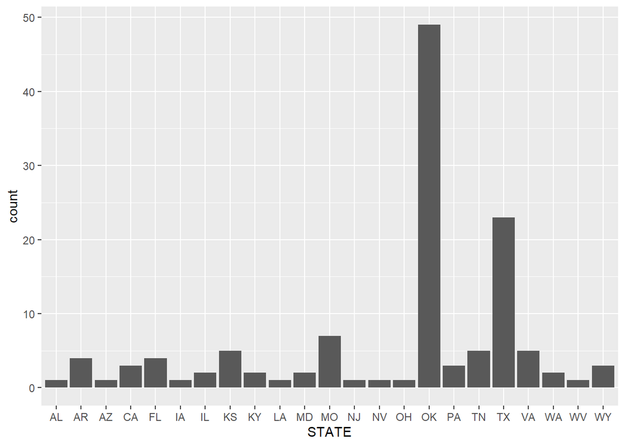

```r
# now we need to plot this output to get counts by state, so we need to use the geom_bar()
df_all %>% filter(TYPE == 'CONV') %>%
  ggplot() +
  geom_bar(aes(x = STATE))
```

```r
# looks good. let's give it a title so that we know what type of loan this graph is for.
df_all %>% filter(TYPE == 'CONV') %>%
  ggplot() +
  geom_bar(aes(x = STATE))  +
  labs(title = 'CONV Loans by State' ,
       y="Count",
       x="State")
```

[output not shown]

This is a pretty good template to start working with for the other loan types. I’ll go ahead and build those out now. I need to know all the different types there are in this data so that I don’t forget to plot any of them.

```r
unique(df_all)
```

```
## # A tibble: 250 x 5
##    ACCT_NBR ORIG_BAL PRIN_BAL STATE TYPE
##       <dbl>    <dbl>    <dbl> <chr> <chr>
##  1      100   382300  188239. OK    CONV
##  2    20002     2700    1080  PA    CONV
##  3   361041    66200   53161. VA    CONV
##  4   362471    14400   12696. MO    CONV
##  5   366186    50000   37652. AR    CONV
##  6   380003   116725   95723. TX    FHA
##  7   391004   180800  147098. TX    CONV
##  8   392000    45306   34048. TX    CONV
##  9   399070   208000  180975. MD    CONV
## 10   399427    95918   77737. OK    USDA
## # ... with 240 more rows
```

Alright, so we have to do seven different plots. Let’s get started on those. I’m just going to copy my code chunk from the CONV plot to do these so I can save some time. (Start the clock.)

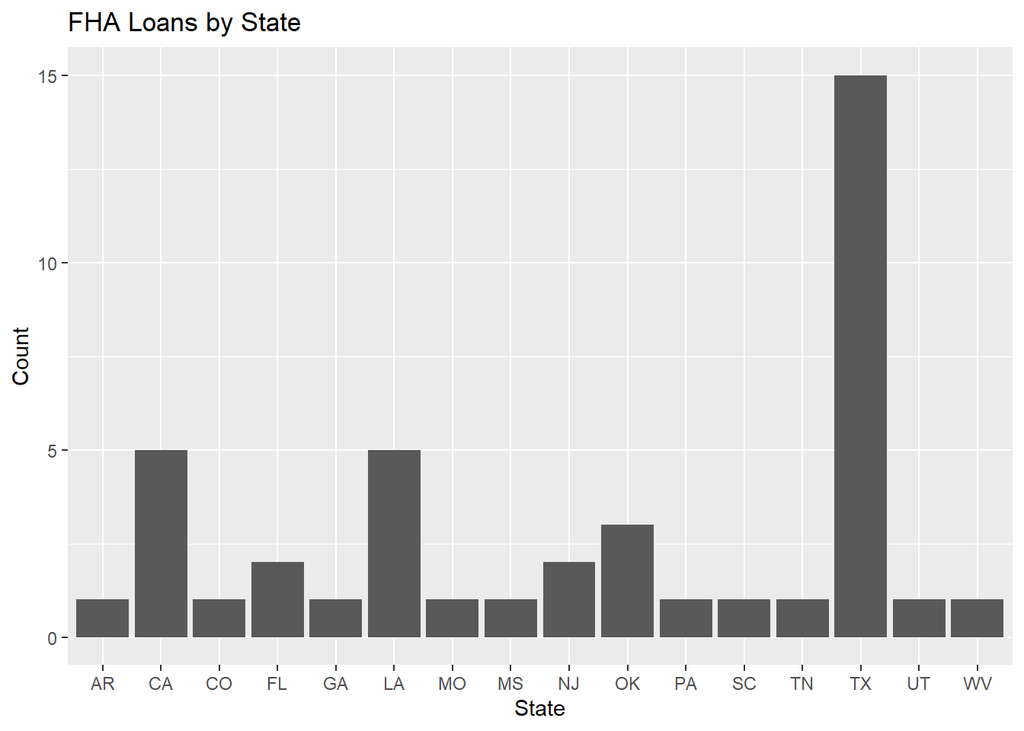

```r
# looks good. let's give it a title so that we know what type of loan this graph is for.
df_all %>% filter(TYPE == 'FHA') %>%
  ggplot() +
  geom_bar(aes(x = STATE))  +
  labs(title = 'FHA Loans by State' ,
       y="Count",
       x="State")
```

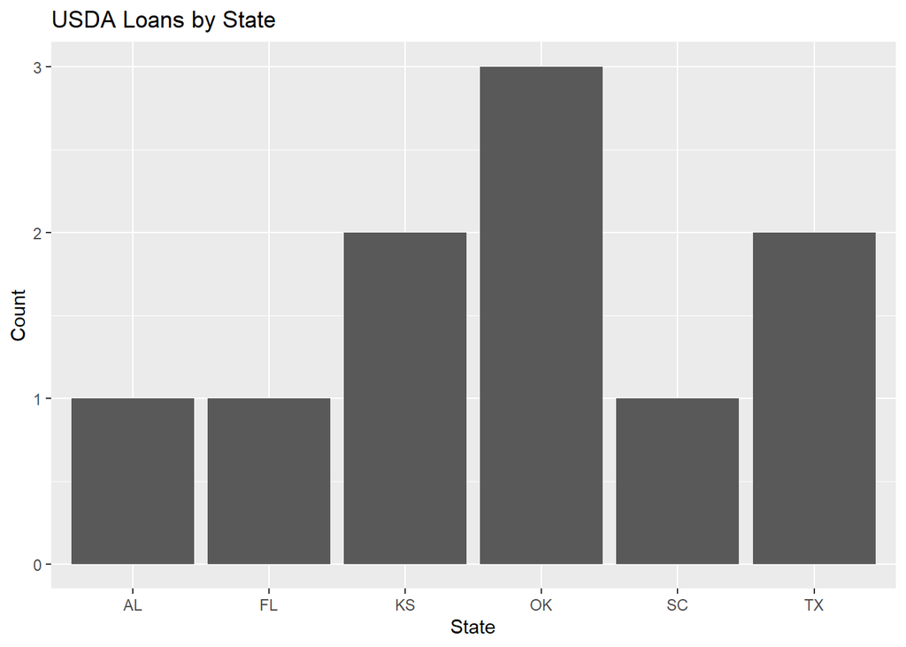

```r
# looks good. let's give it a title so that we know what type of loan this graph is for.
df_all %>% filter(TYPE == 'USDA') %>%
  ggplot() +
  geom_bar(aes(x = STATE))  +
  labs(title = 'USDA Loans by State' ,
       y="Count",
       x="State")
```

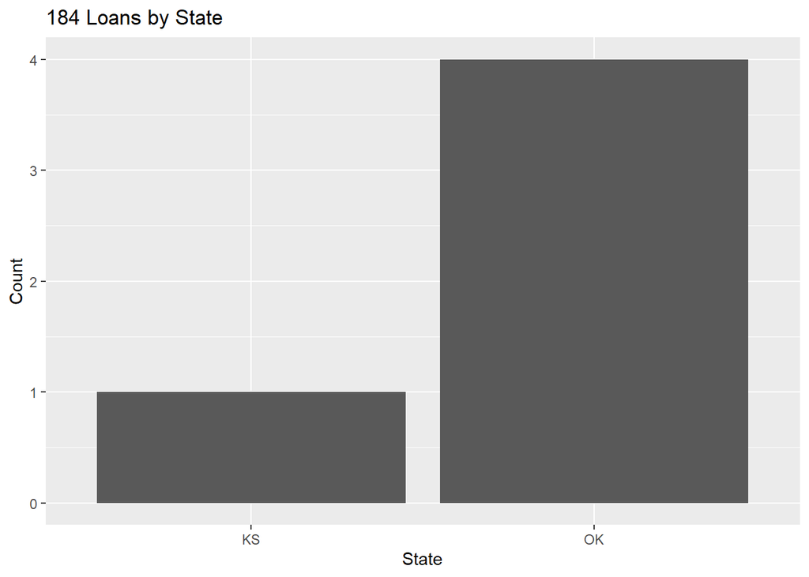

```r
# looks good. let's give it a title so that we know what type of loan this graph is for.
df_all %>% filter(TYPE == '184') %>%
  ggplot() +
  geom_bar(aes(x = STATE))  +
  labs(title = '184 Loans by State' ,
       y="Count",
       x="State")
```

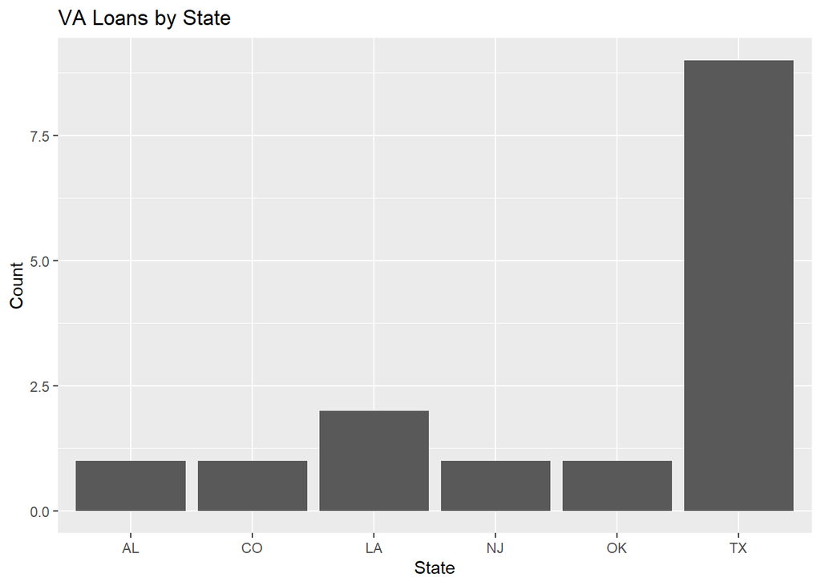

```r
# looks good. let's give it a title so that we know what type of loan this graph is for.
df_all %>% filter(TYPE == 'VA') %>%
  ggplot() +
  geom_bar(aes(x = STATE))  +
  labs(title = 'VA Loans by State' ,
       y="Count",
       x="State")
```

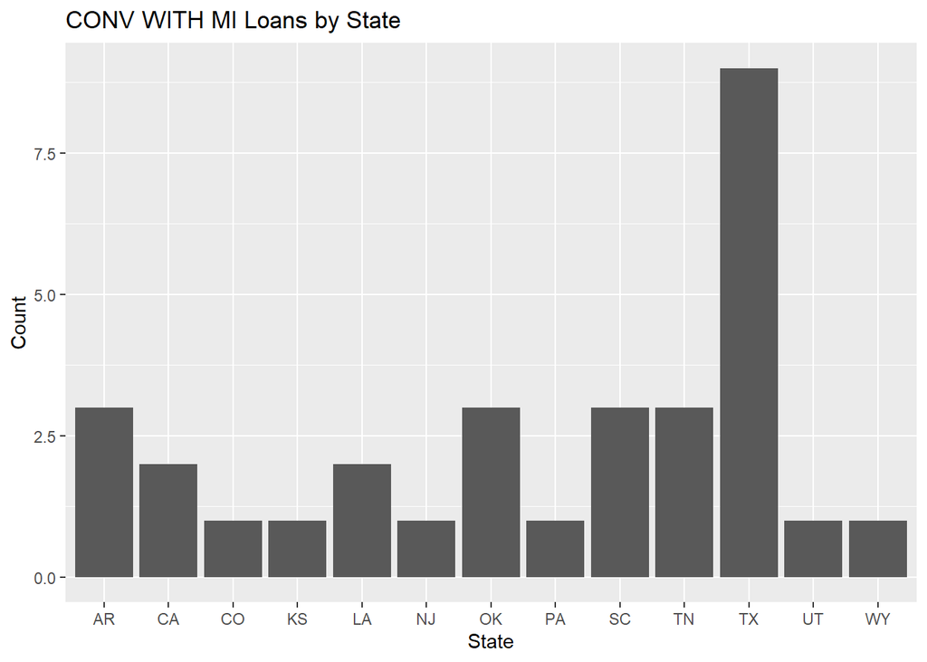

```r
# looks good. let's give it a title so that we know what type of loan this graph is for.
df_all %>% filter(TYPE == 'CONV WITH MI') %>%
  ggplot() +
  geom_bar(aes(x = STATE))  +
  labs(title = 'CONV WITH MI Loans by State' ,
       y="Count",
       x="State")
```

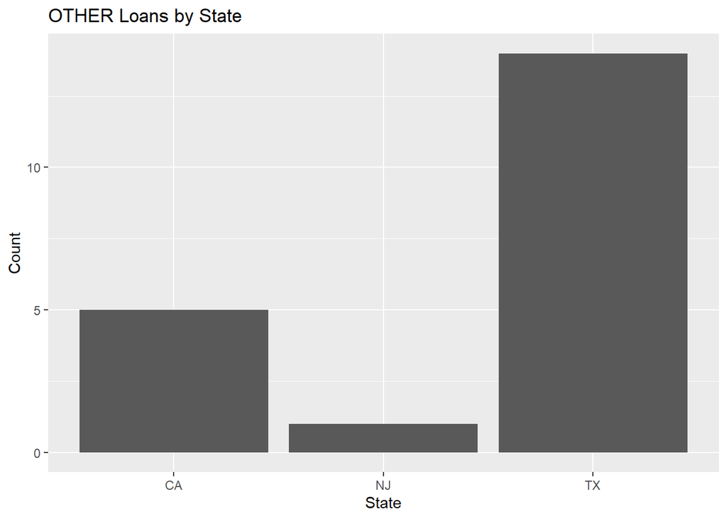

```r
# looks good. let's give it a title so that we know what type of loan this graph is for.
df_all %>% filter(TYPE == 'OTHER') %>%
  ggplot() +
  geom_bar(aes(x = STATE))  +
  labs(title = 'OTHER Loans by State' ,
       y="Count",
       x="State")
```

Oops, I forgot to put a subtitle on the top to show how up to date my data is. Better do that now.

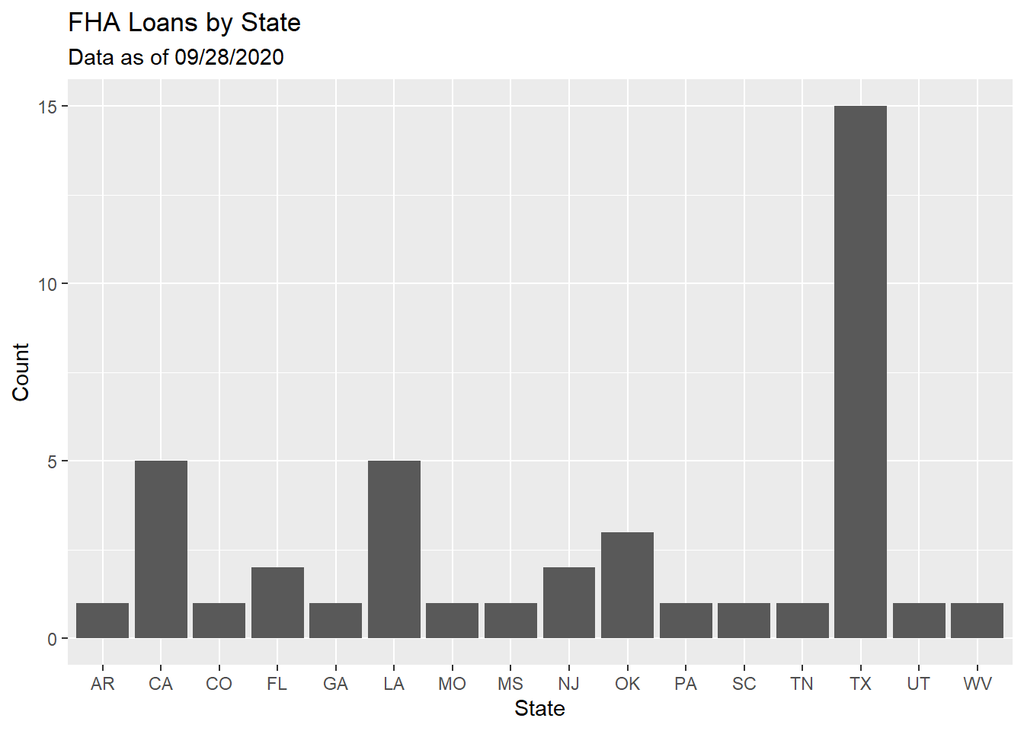

```r
# looks good. let's give it a title so that we know what type of loan this graph is for.
df_all %>% filter(TYPE == 'FHA') %>%
  ggplot() +
  geom_bar(aes(x = STATE))  +
  labs(title = 'FHA Loans by State' ,
       subtitle = 'Data as of 09/28/2020',
       y="Count",
       x="State")
```

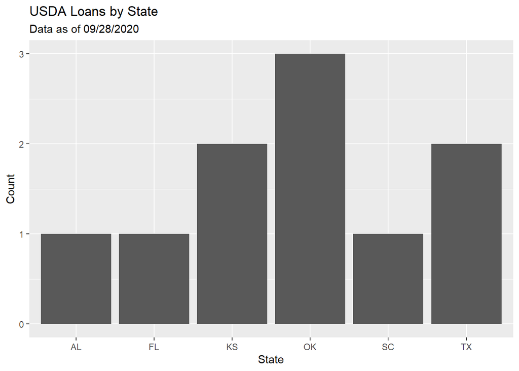

```r
# looks good. let's give it a title so that we know what type of loan this graph is for.
df_all %>% filter(TYPE == 'USDA') %>%
  ggplot() +
  geom_bar(aes(x = STATE))  +
  labs(title = 'USDA Loans by State' ,
       subtitle = 'Data as of 09/28/2020',
       y="Count",
       x="State")
```

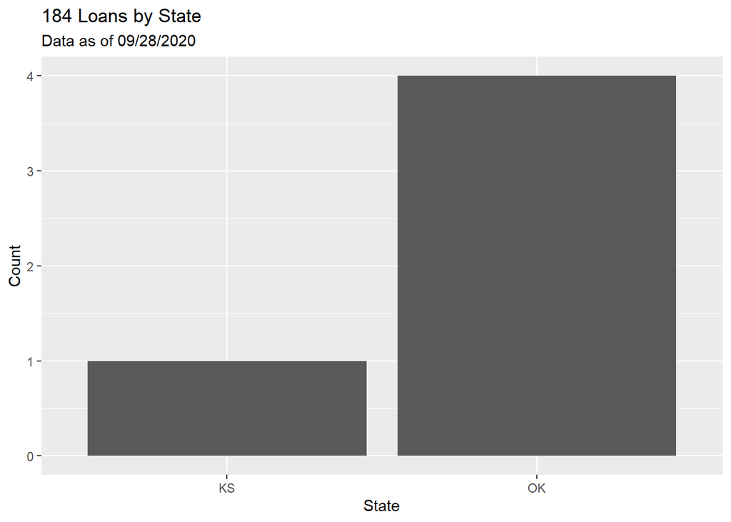

```r
# looks good. let's give it a title so that we know what type of loan this graph is for.
df_all %>% filter(TYPE == '184') %>%
  ggplot() +
  geom_bar(aes(x = STATE))  +
  labs(title = '184 Loans by State' ,
       subtitle = 'Data as of 09/28/2020',
       y="Count",
       x="State")
```

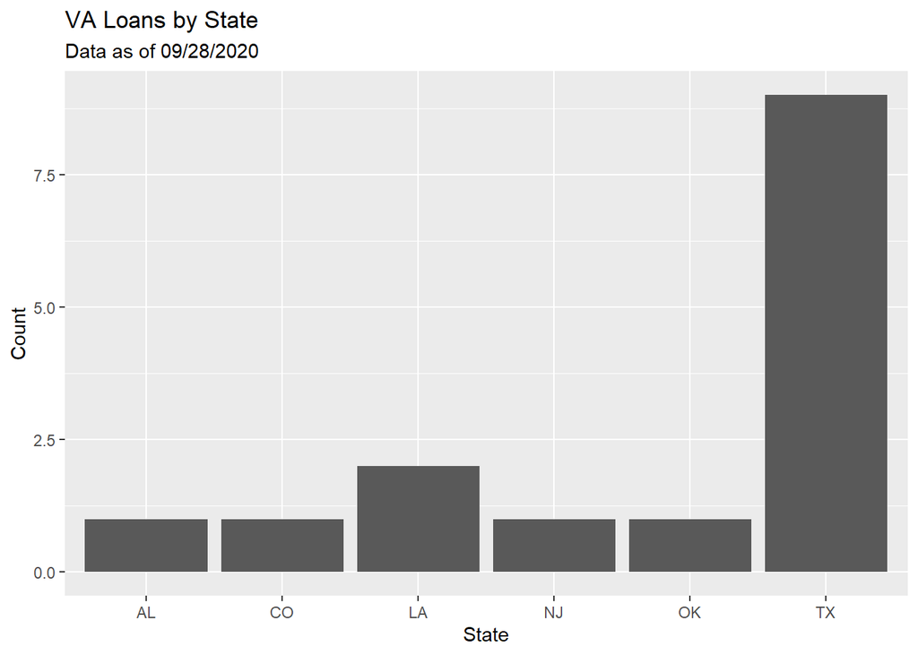

```r
# looks good. let's give it a title so that we know what type of loan this graph is for.
df_all %>% filter(TYPE == 'VA') %>%
  ggplot() +
  geom_bar(aes(x = STATE))  +
  labs(title = 'VA Loans by State' ,
       subtitle = 'Data as of 09/28/2020',
       y="Count",
       x="State")
```

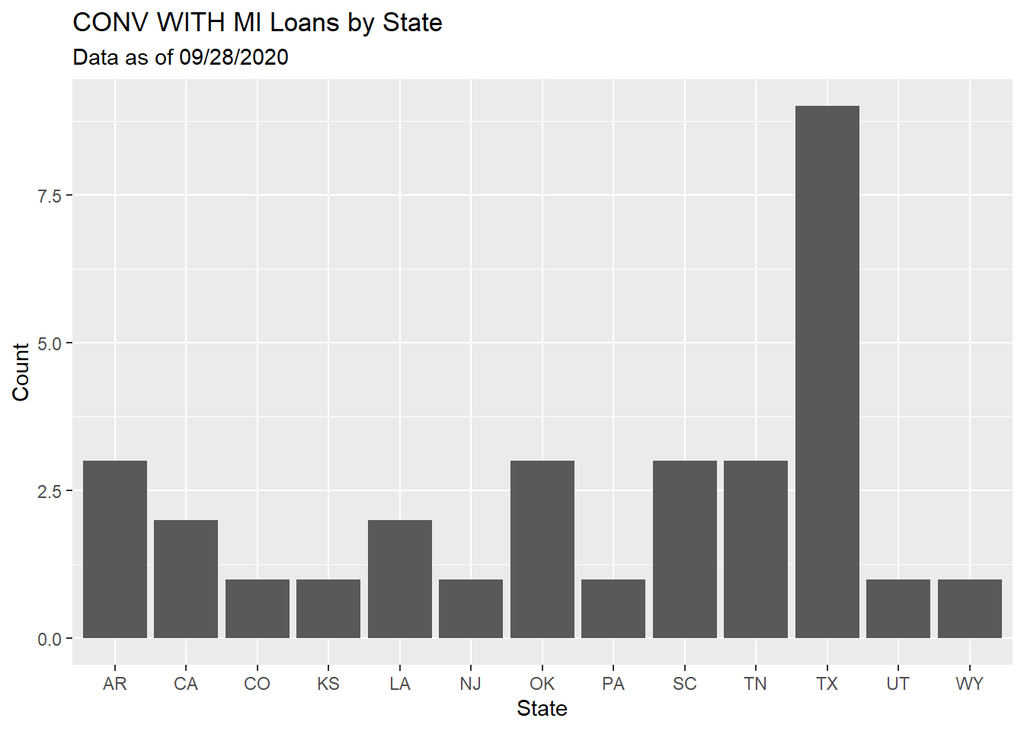

```r
# looks good. let's give it a title so that we know what type of loan this graph is for.
df_all %>% filter(TYPE == 'CONV WITH MI') %>%
  ggplot() +
  geom_bar(aes(x = STATE))  +
  labs(title = 'CONV WITH MI Loans by State' ,
       subtitle = 'Data as of 09/28/2020',
       y="Count",
       x="State")
```

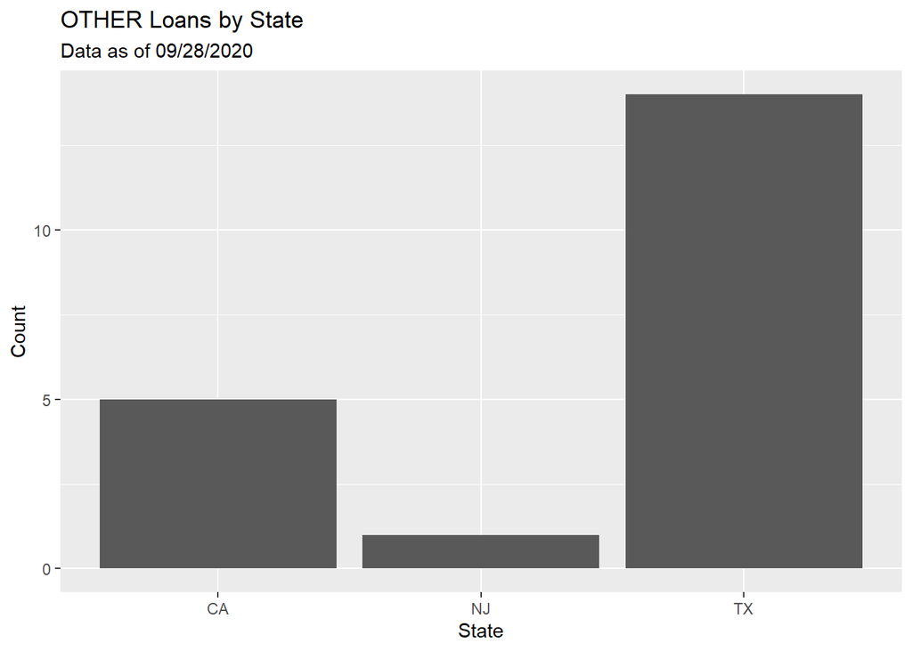

```r
# looks good. let's give it a title so that we know what type of loan this graph is for.
df_all %>% filter(TYPE == 'OTHER') %>%
  ggplot() +
  geom_bar(aes(x = STATE))  +
  labs(title = 'OTHER Loans by State' ,
       subtitle = 'Data as of 09/28/2020',
       y="Count",
       x="State")
```

OMG, I forgot to put the source for the data. Since I want people to take me seriously as an analyst, I better go add that.

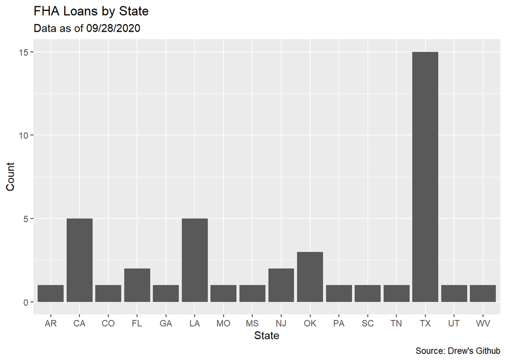

```r
# looks good. let's give it a title so that we know what type of loan this graph is for.
df_all %>% filter(TYPE == 'FHA') %>%
  ggplot() +
  geom_bar(aes(x = STATE))  +
  labs(title = 'FHA Loans by State' ,
       subtitle = 'Data as of 09/28/2020',
       y="Count",
       x="State",
       caption = 'Source: Drew\'s Github')
```

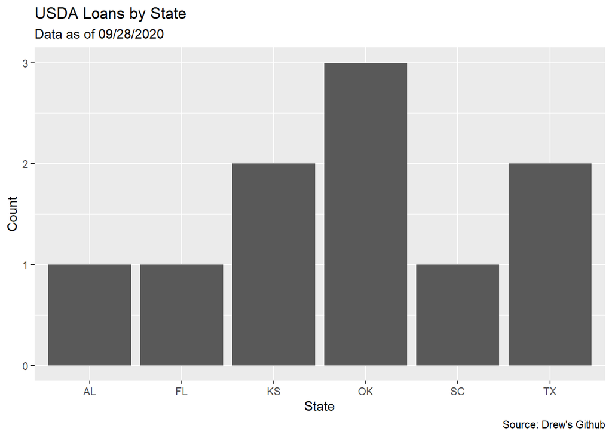

```r
# looks good. let's give it a title so that we know what type of loan this graph is for.
df_all %>% filter(TYPE == 'USDA') %>%
  ggplot() +
  geom_bar(aes(x = STATE))  +
  labs(title = 'USDA Loans by State' ,
       subtitle = 'Data as of 09/28/2020',
       y="Count",
       x="State",
       caption = 'Source: Drew\'s Github')
```

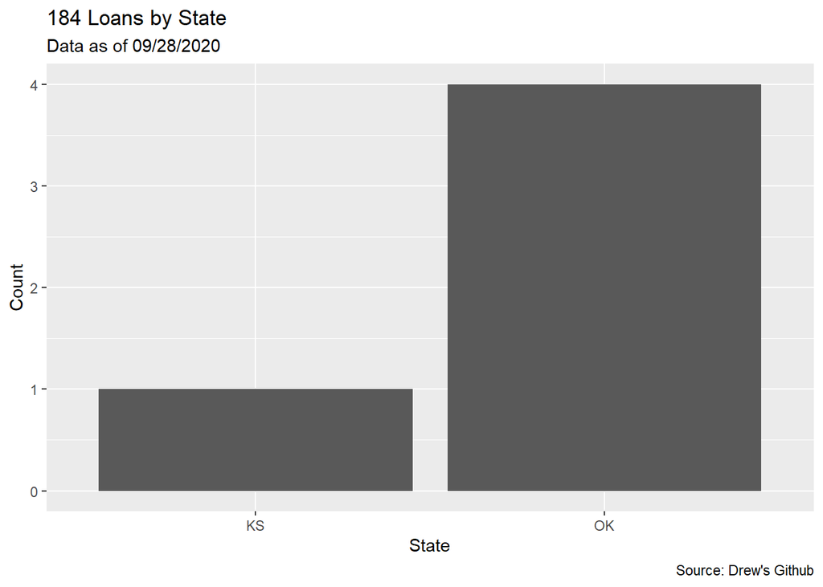

```r
# looks good. let's give it a title so that we know what type of loan this graph is for.
df_all %>% filter(TYPE == '184') %>%
  ggplot() +
  geom_bar(aes(x = STATE))  +
  labs(title = '184 Loans by State' ,
       subtitle = 'Data as of 09/28/2020',
       y="Count",
       x="State",
       caption = 'Source: Drew\'s Github')
```

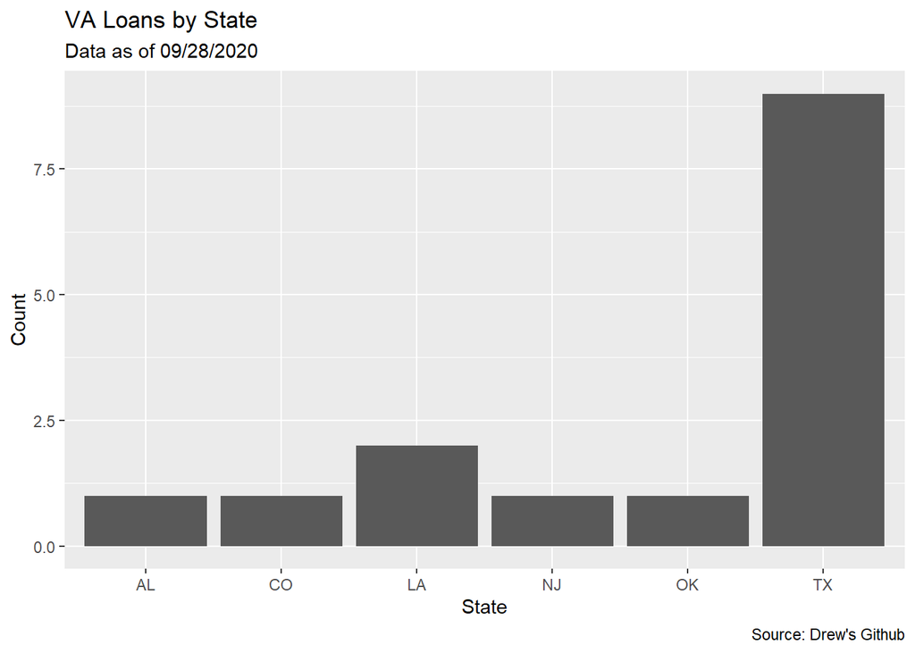

```r
# looks good. let's give it a title so that we know what type of loan this graph is for.
df_all %>% filter(TYPE == 'VA') %>%
  ggplot() +
  geom_bar(aes(x = STATE))  +
  labs(title = 'VA Loans by State' ,
       subtitle = 'Data as of 09/28/2020',
       y="Count",
       x="State",
       caption = 'Source: Drew\'s Github')
```

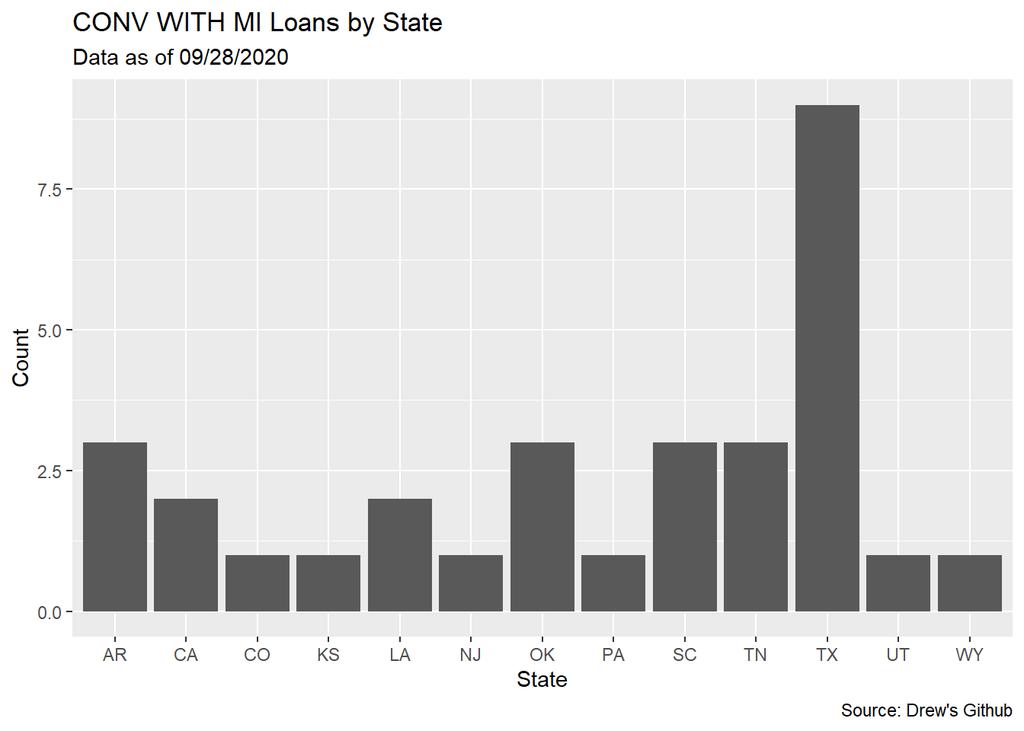

```r
# looks good. let's give it a title so that we know what type of loan this graph is for.
df_all %>% filter(TYPE == 'CONV WITH MI') %>%
  ggplot() +
  geom_bar(aes(x = STATE))  +
  labs(title = 'CONV WITH MI Loans by State' ,
       subtitle = 'Data as of 09/28/2020',
       y="Count",
       x="State",
       caption = 'Source: Drew\'s Github')
```

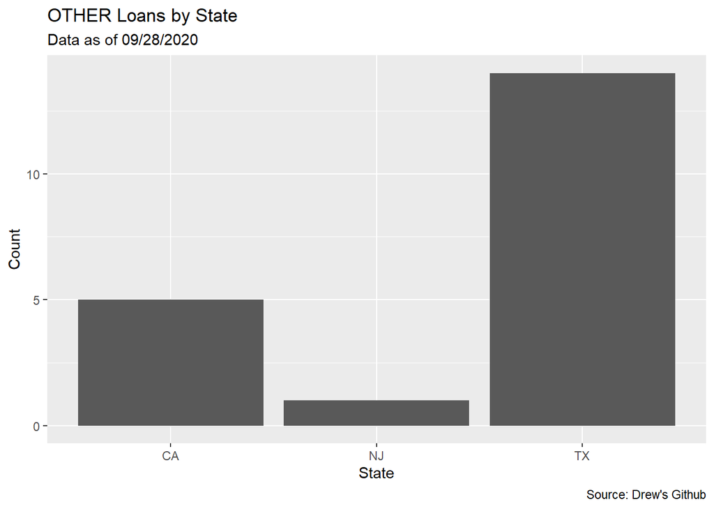

```r
# looks good. let's give it a title so that we know what type of loan this graph is for.
df_all %>% filter(TYPE == 'OTHER') %>%
  ggplot() +
  geom_bar(aes(x = STATE))  +
  labs(title = 'OTHER Loans by State' ,
       subtitle = 'Data as of 09/28/2020',
       y="Count",
       x="State",
       caption = 'Source: Drew\'s Github')
```

Dangit, now I want to change the theme and the color so they look more professional. Better do that now.

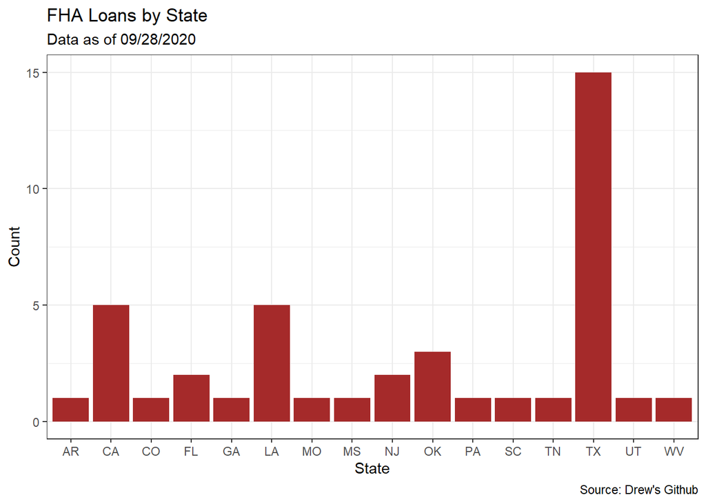

```r
# looks good. let's give it a title so that we know what type of loan this graph is for.
df_all %>% filter(TYPE == 'FHA') %>%
  ggplot() +
  geom_bar(aes(x = STATE), fill = 'brown')  +
  labs(title = 'FHA Loans by State' ,
       subtitle = 'Data as of 09/28/2020',
       y="Count",
       x="State",
       caption = 'Source: Drew\'s Github') +
  theme_bw()
```

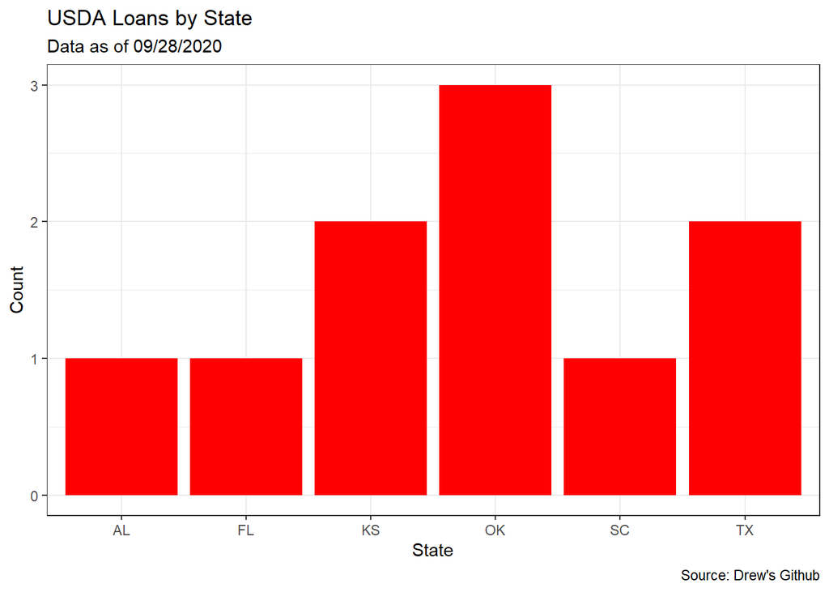

```r
# looks good. let's give it a title so that we know what type of loan this graph is for.
df_all %>% filter(TYPE == 'USDA') %>%
  ggplot() +
  geom_bar(aes(x = STATE), fill = 'red')  +
  labs(title = 'USDA Loans by State' ,
       subtitle = 'Data as of 09/28/2020',
       y="Count",
       x="State",
       caption = 'Source: Drew\'s Github') +
  theme_bw()
```

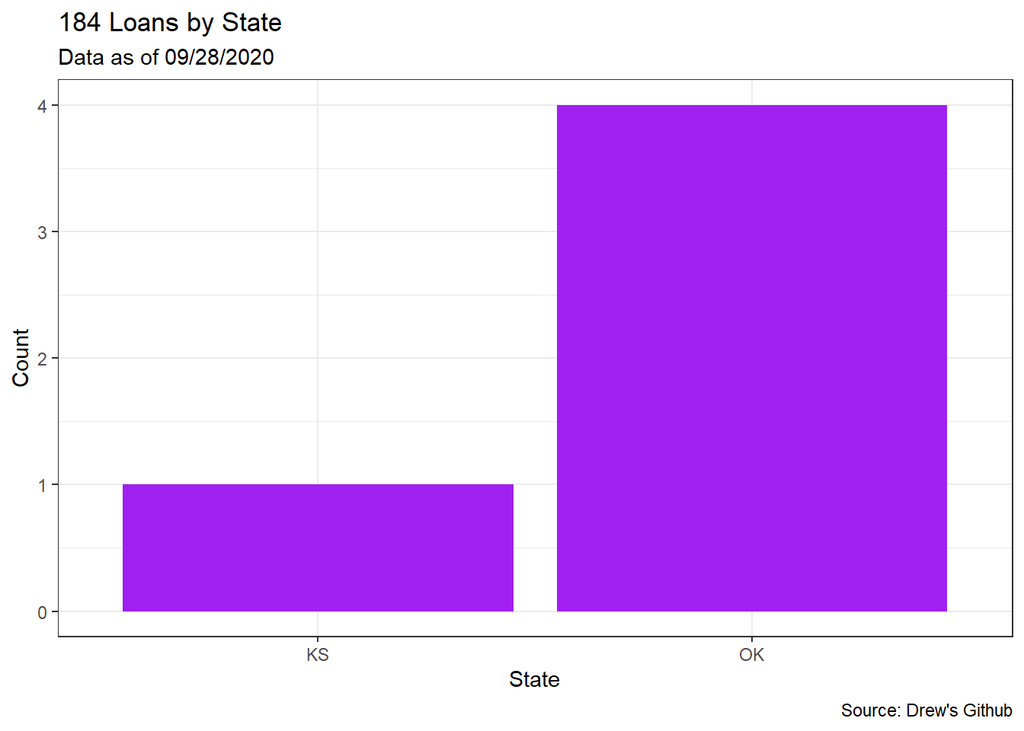

```r
# looks good. let's give it a title so that we know what type of loan this graph is for.
df_all %>% filter(TYPE == '184') %>%
  ggplot() +
  geom_bar(aes(x = STATE), fill = 'purple')  +
  labs(title = '184 Loans by State' ,
       subtitle = 'Data as of 09/28/2020',
       y="Count",
       x="State",
       caption = 'Source: Drew\'s Github') +
  theme_bw()
```

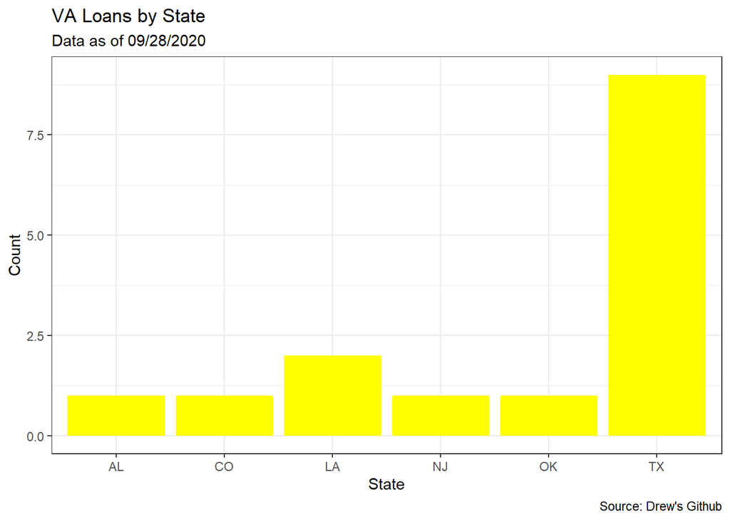

```r
# looks good. let's give it a title so that we know what type of loan this graph is for.
df_all %>% filter(TYPE == 'VA') %>%
  ggplot() +
  geom_bar(aes(x = STATE), fill = 'yellow')  +
  labs(title = 'VA Loans by State' ,
       subtitle = 'Data as of 09/28/2020',
       y="Count",
       x="State",
       caption = 'Source: Drew\'s Github') +
  theme_bw()
```

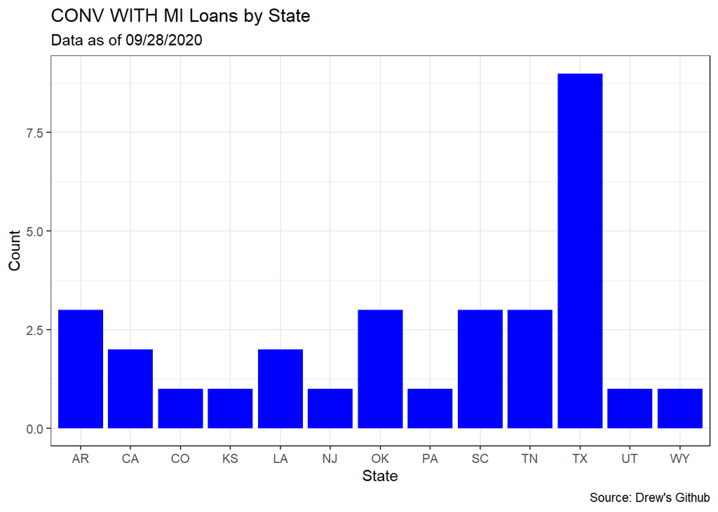

```r
# looks good. let's give it a title so that we know what type of loan this graph is for.
df_all %>% filter(TYPE == 'CONV WITH MI') %>%
  ggplot() +
  geom_bar(aes(x = STATE), fill = 'blue')  +
  labs(title = 'CONV WITH MI Loans by State' ,
       subtitle = 'Data as of 09/28/2020',
       y="Count",
       x="State",
       caption = 'Source: Drew\'s Github') +
  theme_bw()
```

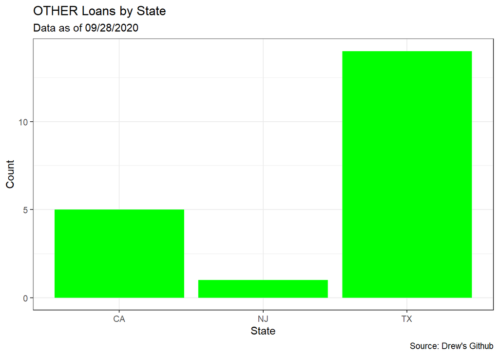

```r
# looks good. let's give it a title so that we know what type of loan this graph is for.
df_all %>% filter(TYPE == 'OTHER') %>%
  ggplot() +
  geom_bar(aes(x = STATE), fill = 'green')  +
  labs(title = 'OTHER Loans by State' ,
       subtitle = 'Data as of 09/28/2020',
       y="Count",
       x="State",
       caption = 'Source: Drew\'s Github') +
  theme_bw()
```

Finally done I think. (stop the clock). UNLESS, I decide to go back and the State label on the x-axis to “property state”… nah, it’s fine. Too much trouble.

> This development process would’ve been so much simpler if we had made a function for it at the beginning. -Every single new developer

Now let’s rewind that whole process and use functions instead. We can compare the amount of time it takes to do both.

(start clock)

Let’s write out the code that we would need to make one of the graphs we want. We’ll use the conventional type first. We want to filter down to just conventional loans, so we’ll need to use %>% and filter() from dplyr. Then we want to make a plot, so we need to use ggplot() from ggplot2.

```r
library(ggplot2)
library(dplyr)

# this command outputs all CONV loans
df_all %>% filter(TYPE == 'CONV')
```

```
## # A tibble: 127 x 5
##    ACCT_NBR ORIG_BAL PRIN_BAL STATE TYPE
##       <dbl>    <dbl>    <dbl> <chr> <chr>
##  1      100   382300  188239. OK    CONV
##  2    20002     2700    1080  PA    CONV
##  3   361041    66200   53161. VA    CONV
##  4   362471    14400   12696. MO    CONV
##  5   366186    50000   37652. AR    CONV
##  6   391004   180800  147098. TX    CONV
##  7   392000    45306   34048. TX    CONV
##  8   399070   208000  180975. MD    CONV
##  9   399930   166500  139714. IL    CONV
## 10   400329   417000  429281. IL    CONV
## # ... with 117 more rows
```

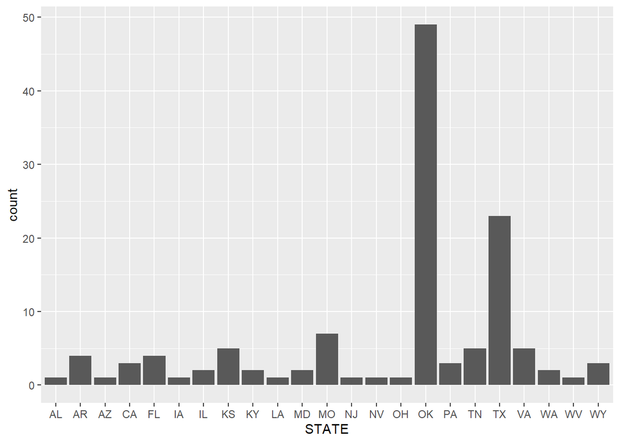

```r
# now we need to plot this output to get counts by state, so we need to use the geom_bar()
df_all %>% filter(TYPE == 'CONV') %>%
  ggplot() +
  geom_bar(aes(x = STATE))
```

```r
# looks good. let's give it a title so that we know what type of loan this graph is for.
df_all %>% filter(TYPE == 'CONV') %>%
  ggplot() +
  geom_bar(aes(x = STATE))  +
  labs(title = 'CONV Loans by State' ,
       y="Count",
       x="State")
```

[output not shown]

Now that we’ve got our plot, let’s make a function so that we can easily apply it to all the other loan types.

```r
plot_type <- function(type){
  df_all %>% filter(TYPE == type) %>%
  ggplot() +
  geom_bar(aes(x = STATE))  +
  labs(title = paste0(type,' Loans by State') ,
       y="Count",
       x="State")
}
```

Let’s plot them all now.

```r
plot_type('CONV')
```

[output not shown]

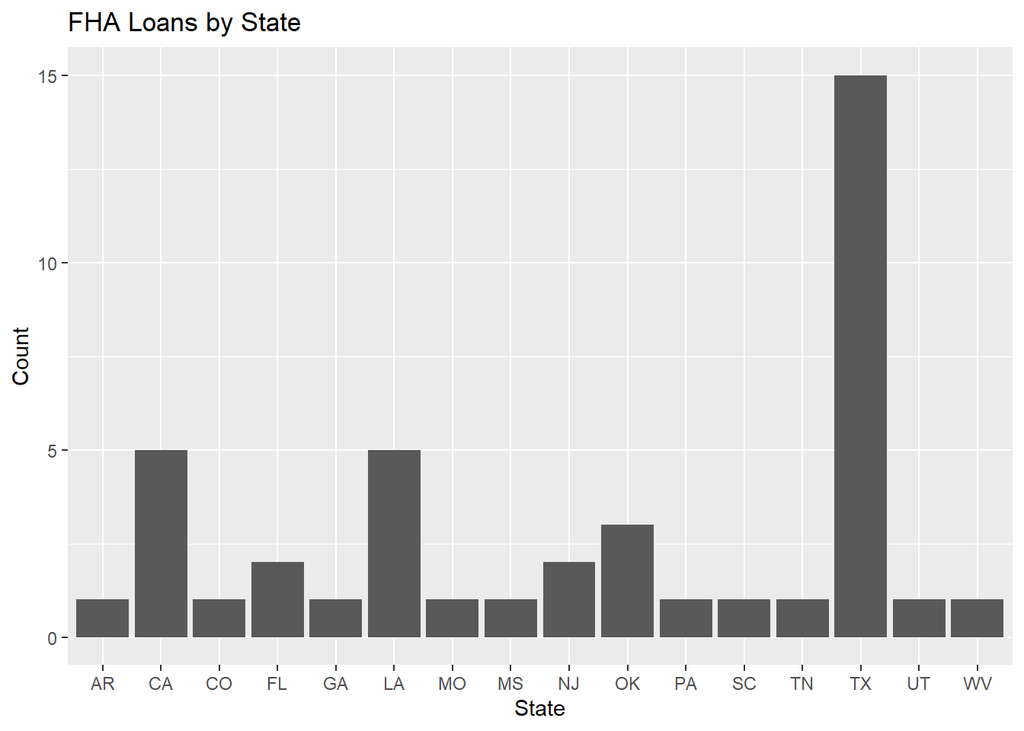

```r
plot_type('FHA')
```

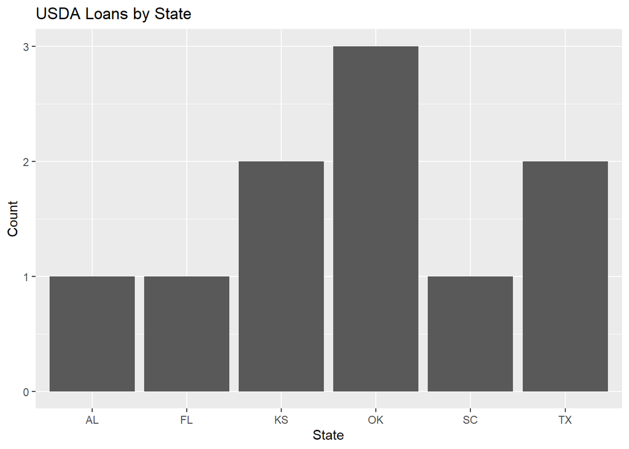

```r
plot_type('USDA')
```

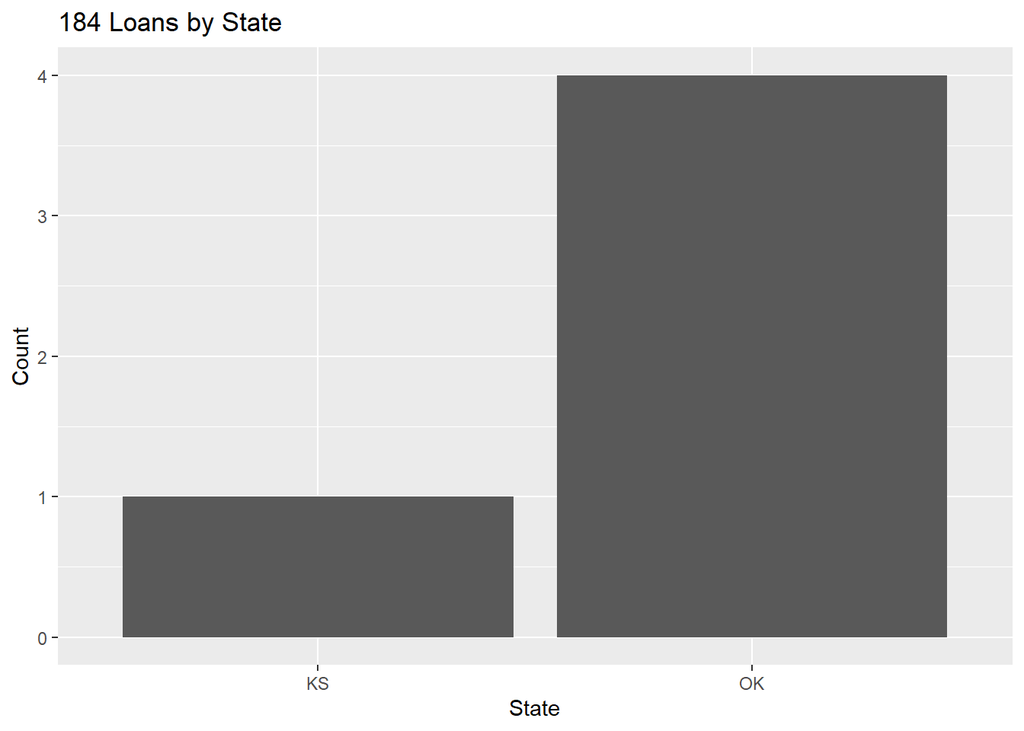

```r
plot_type('184')
```

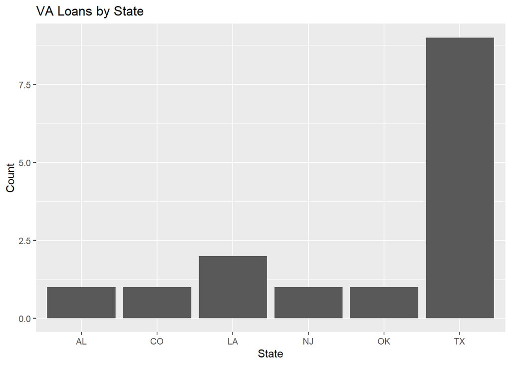

```r
plot_type('VA')
```

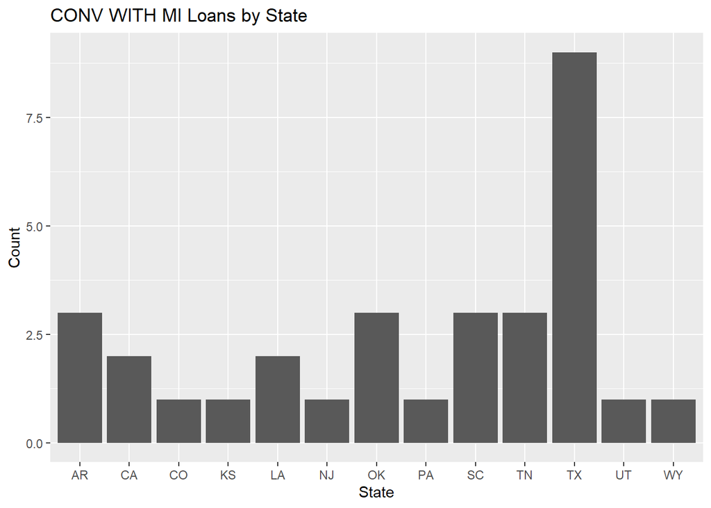

```r
plot_type('CONV WITH MI')
```

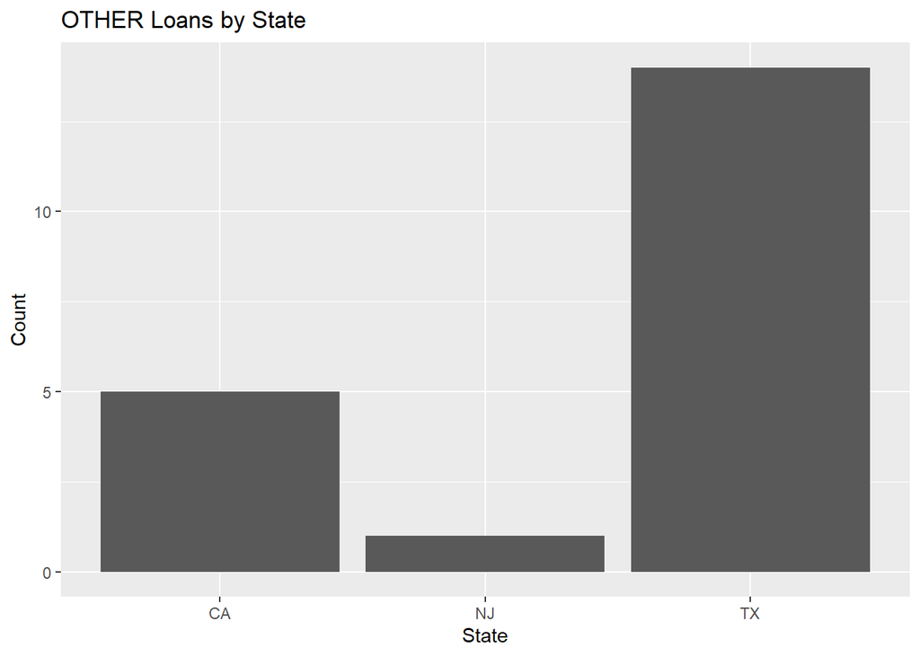

```r
plot_type('OTHER')
```

Oops, I forgot to put a subtitle on the top to show how up to date my data is. Better do that now.

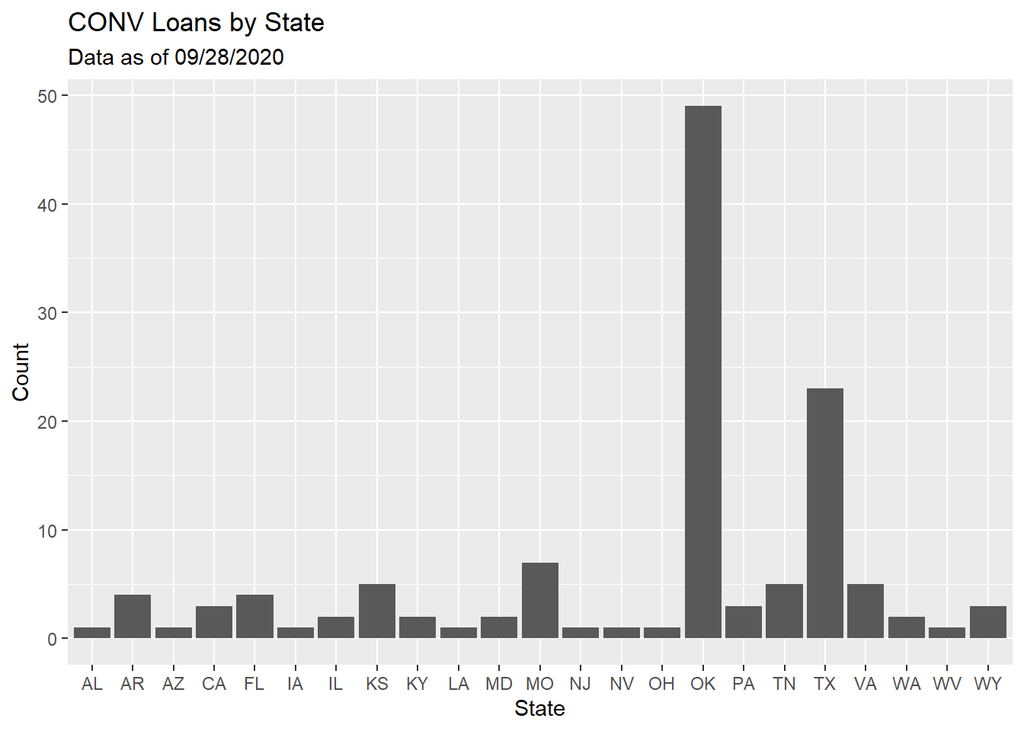

```r
plot_type <- function(type){
  df_all %>% filter(TYPE == type) %>%
  ggplot() +
  geom_bar(aes(x = STATE))  +
  labs(title = paste0(type,' Loans by State') ,
       subtitle = 'Data as of 09/28/2020',
       y="Count",
       x="State")
}

# Let's plot them all again now.
plot_type('CONV')
```

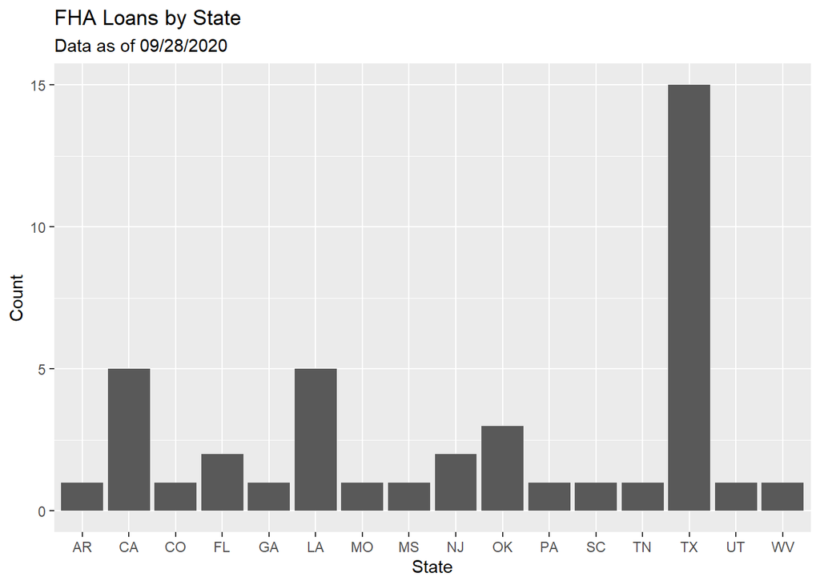

```r
plot_type('FHA')
```

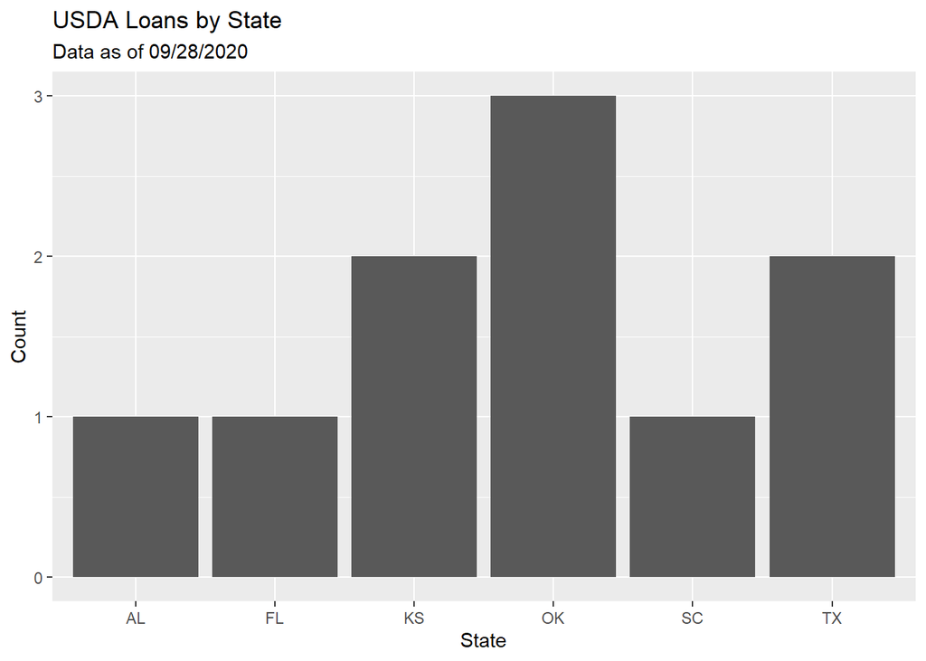

```r
plot_type('USDA')
```

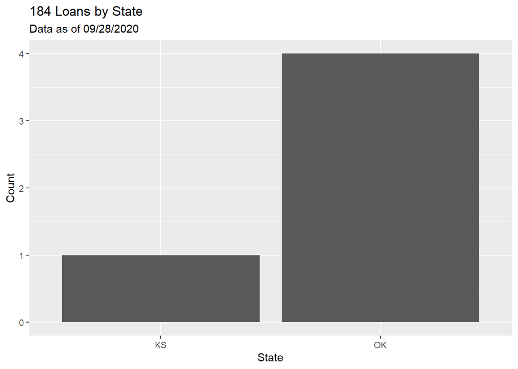

```r
plot_type('184')
```

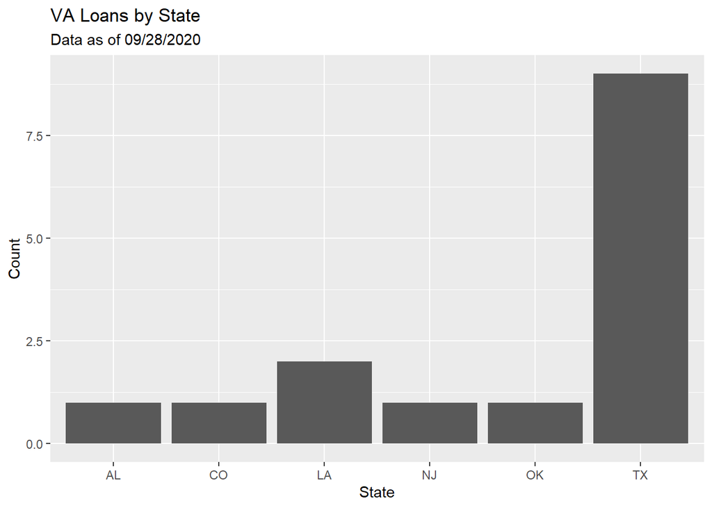

```r
plot_type('VA')
```

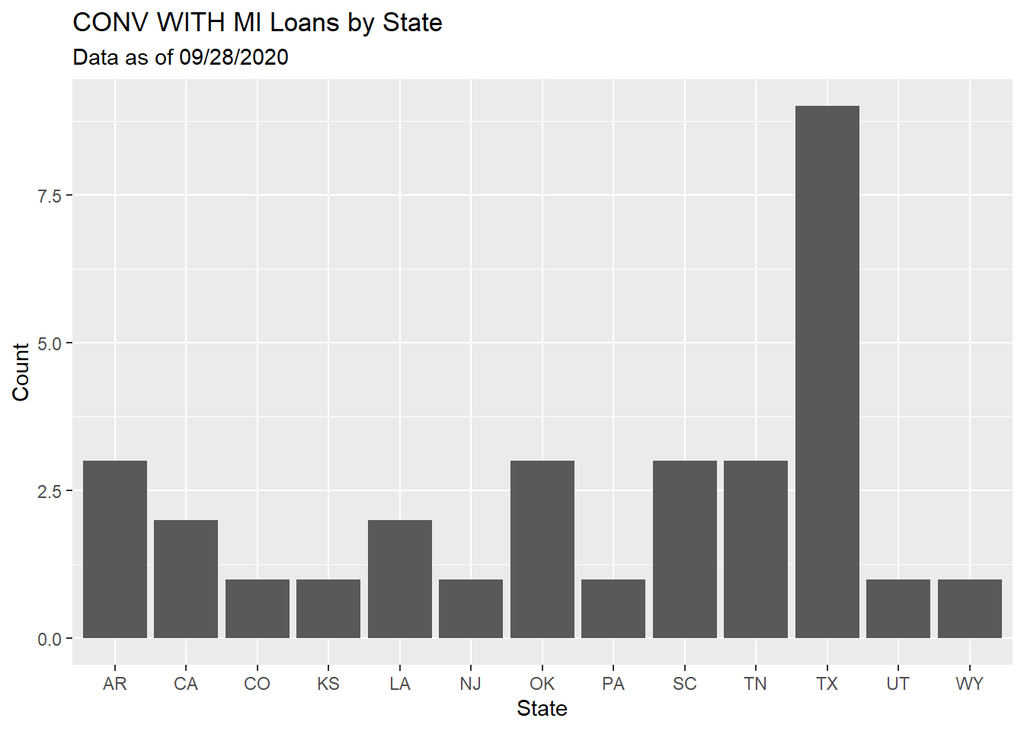

```r
plot_type('CONV WITH MI')
```

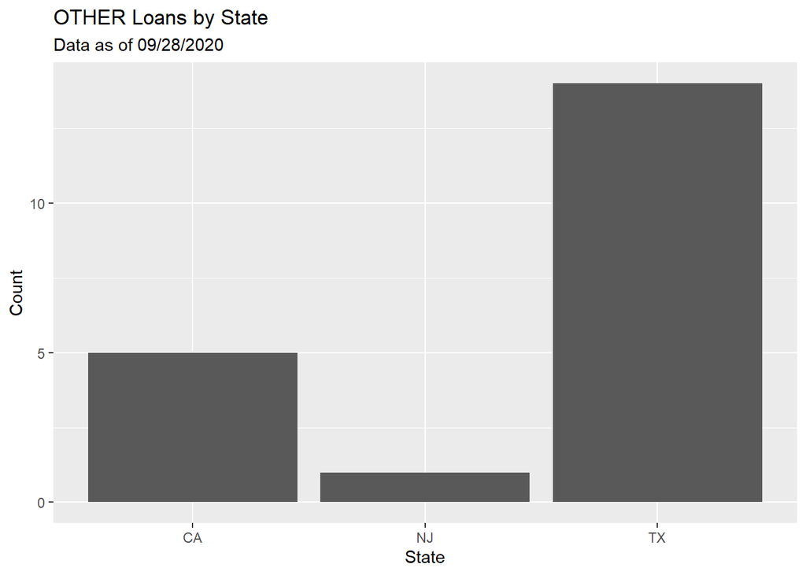

```r
plot_type('OTHER')
```

OMG, I forgot to put the source for the data. Since I want people to take me seriously as an analyst, I better go add that.

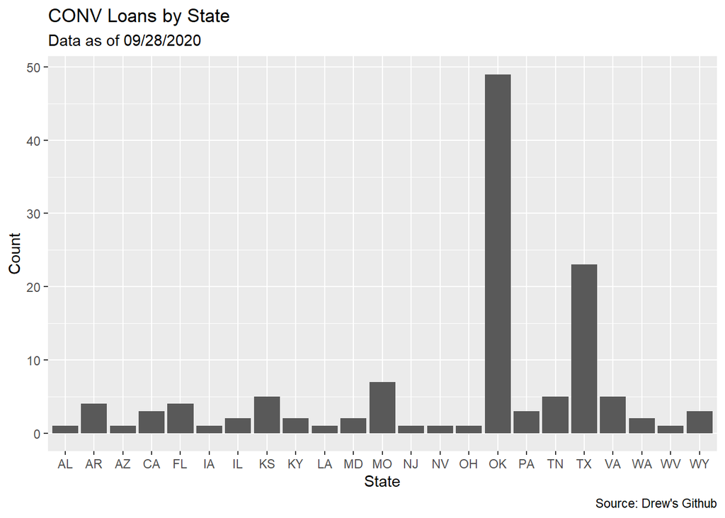

```r
plot_type <- function(type){
  df_all %>% filter(TYPE == type) %>%
  ggplot() +
  geom_bar(aes(x = STATE))  +
  labs(title = paste0(type,' Loans by State') ,
       subtitle = 'Data as of 09/28/2020',
       y="Count",
       x="State",
       caption = 'Source: Drew\'s Github')
}

# Let's plot them all again now.
plot_type('CONV')
```

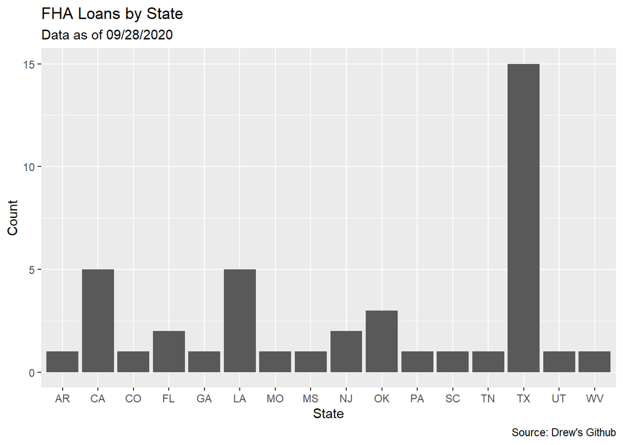

```r
plot_type('FHA')
```

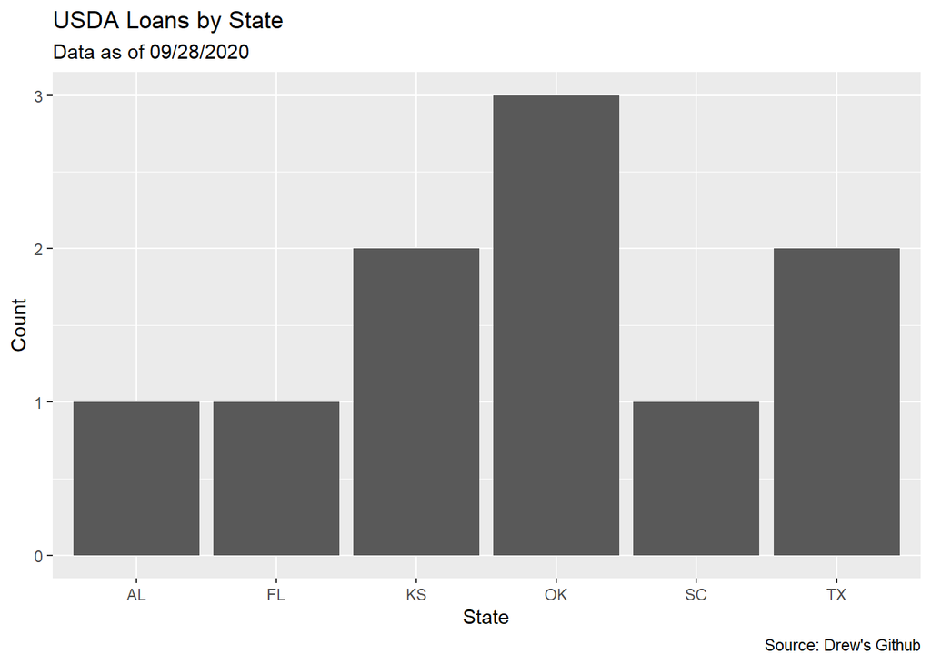

```r
plot_type('USDA')
```

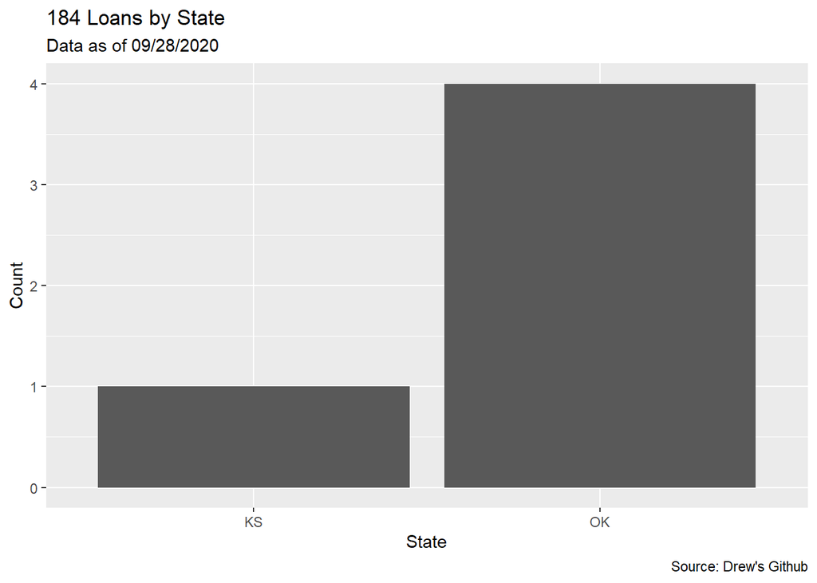

```r
plot_type('184')
```

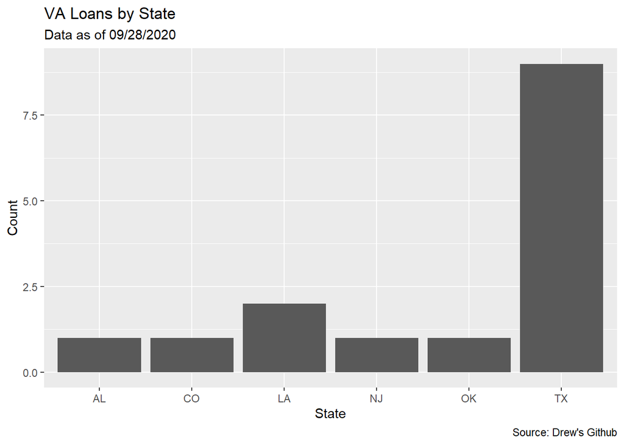

```r
plot_type('VA')
```

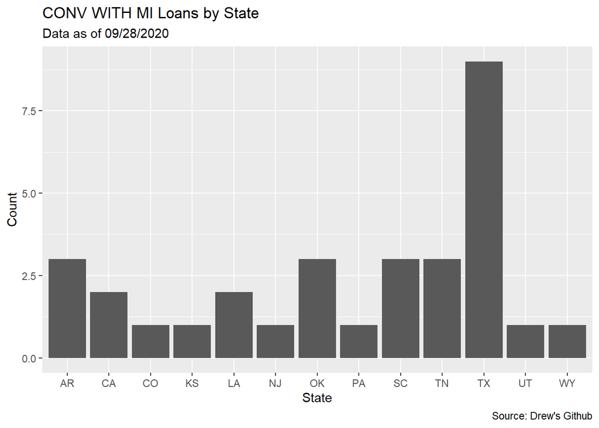

```r
plot_type('CONV WITH MI')
```

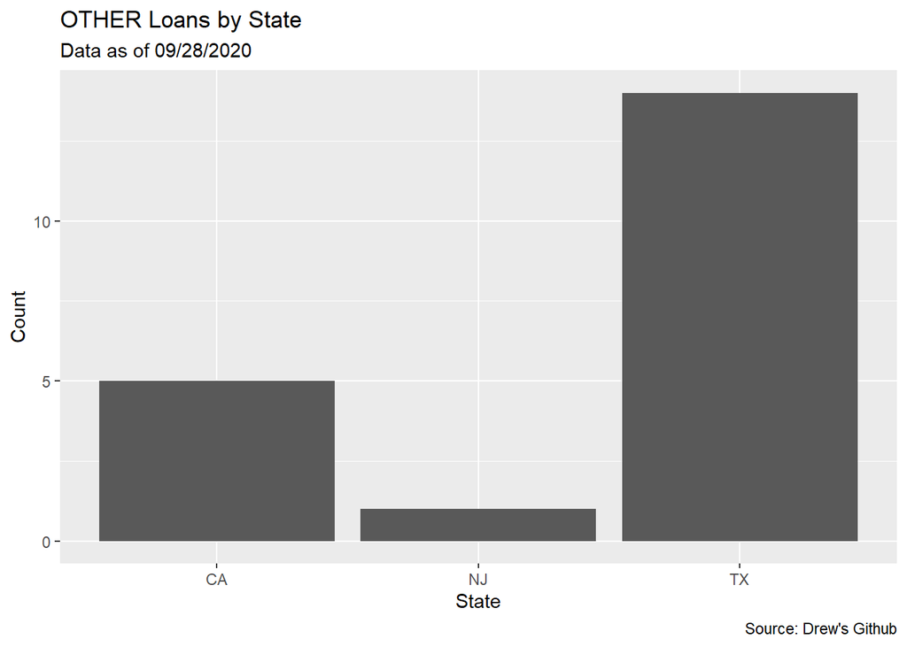

```r
plot_type('OTHER')
```

Dangit, now I want to change the theme and the color so they look more professional. Better do that now.

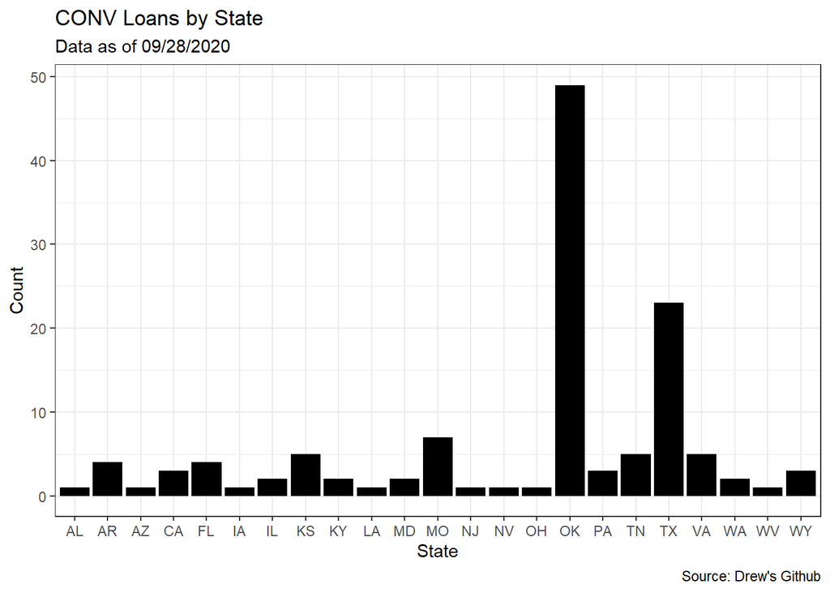

```r
plot_type <- function(type, color){
  df_all %>% filter(TYPE == type) %>%
  ggplot() +
  geom_bar(aes(x = STATE), fill = color)  +
  labs(title = paste0(type,' Loans by State') ,
       subtitle = 'Data as of 09/28/2020',
       y="Count",
       x="State",
       caption = 'Source: Drew\'s Github')  +
  theme_bw()
}

# Let's plot them all again now.
plot_type('CONV', 'black')
```

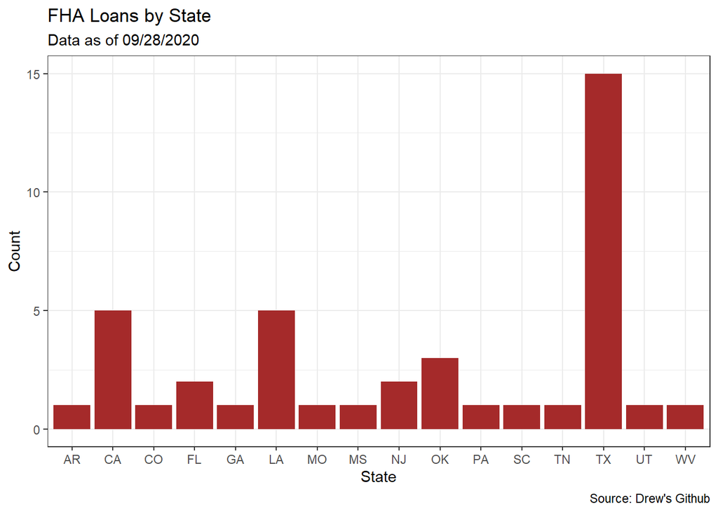

```r
plot_type('FHA', 'brown')
```

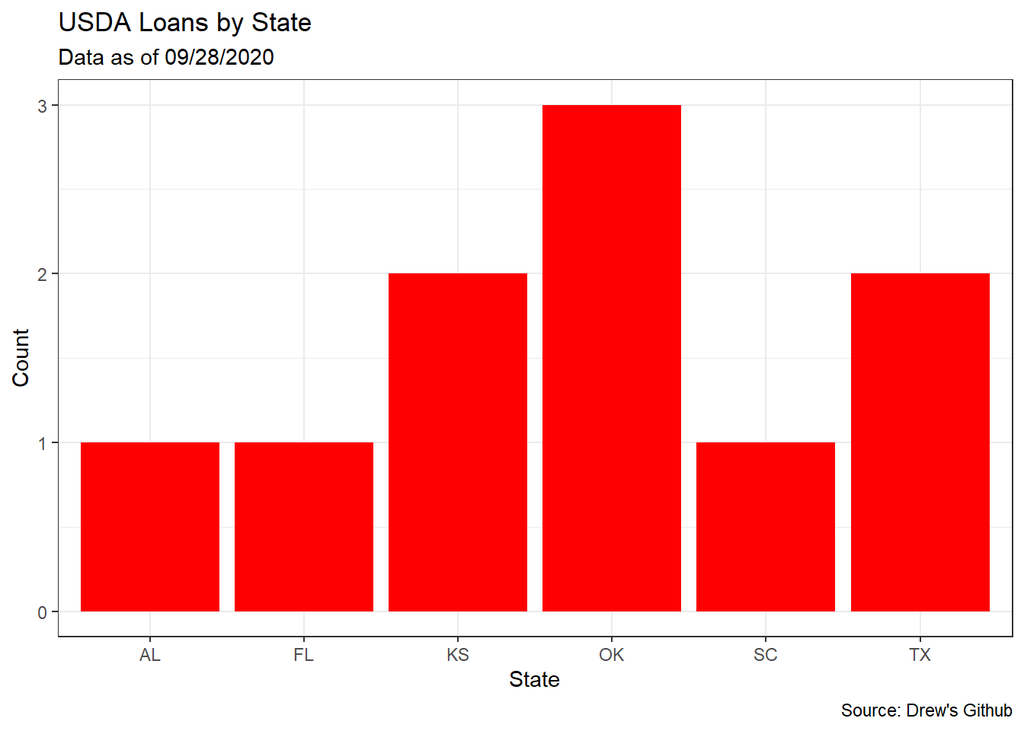

```r
plot_type('USDA', 'red')
```

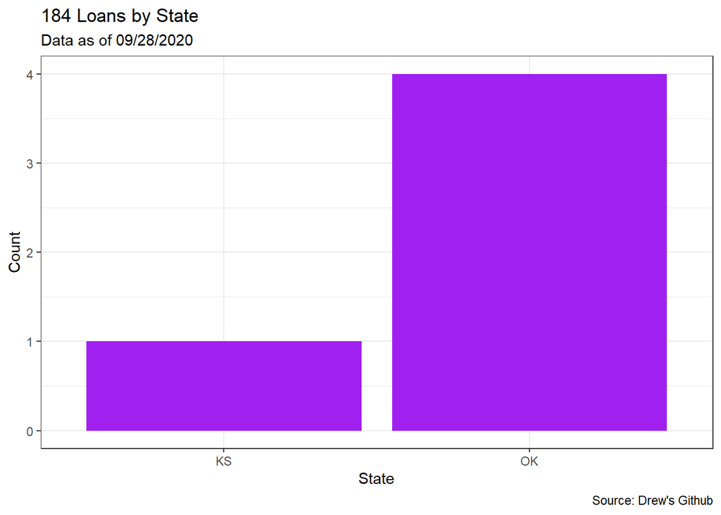

```r
plot_type('184', 'purple')
```

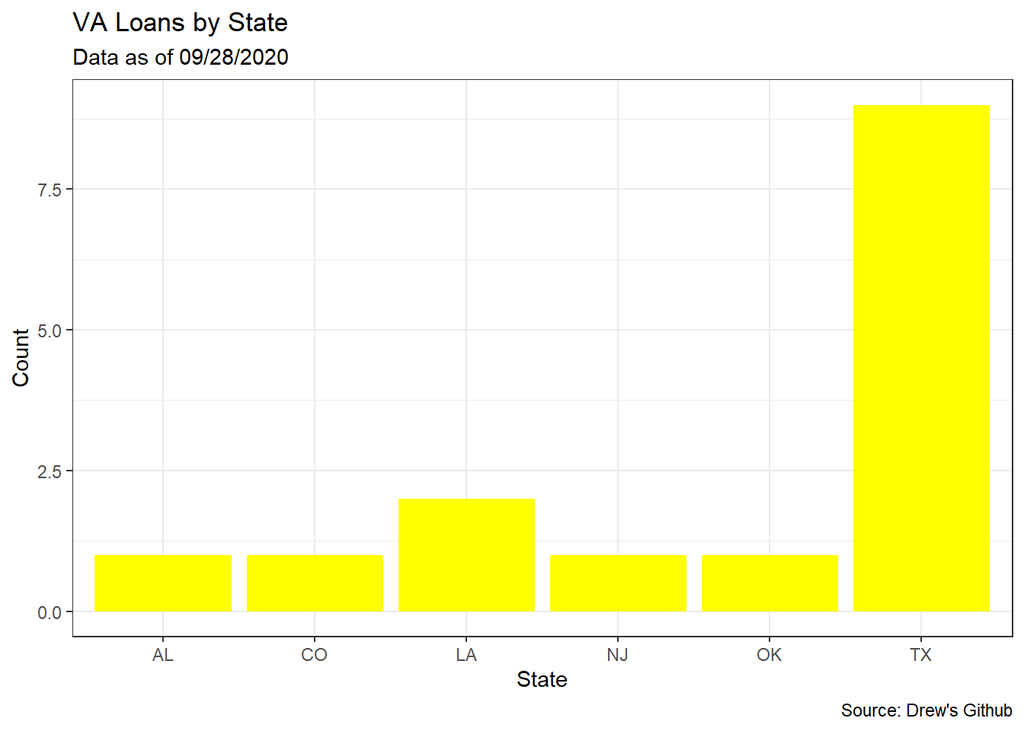

```r
plot_type('VA', 'yellow')
```

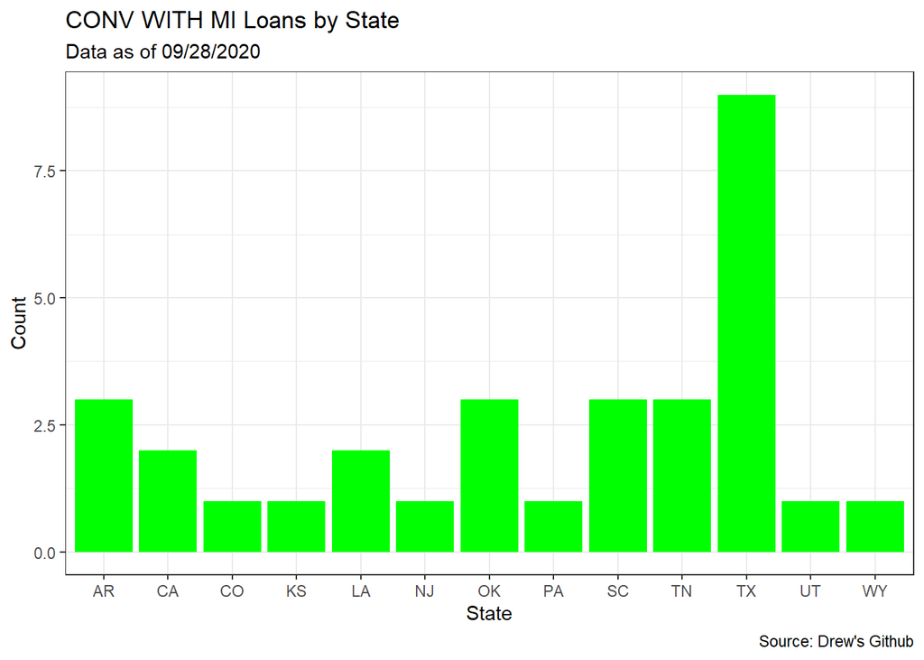

```r
plot_type('CONV WITH MI', 'green')
```

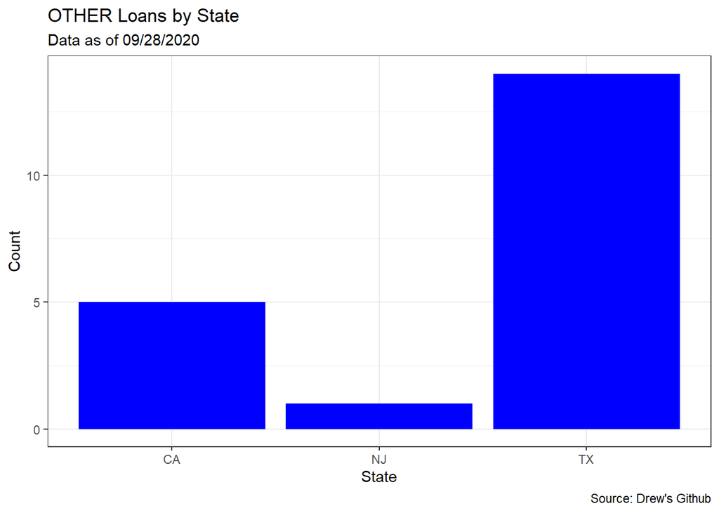

```r
plot_type('OTHER', 'blue')
```

Finally done I think. (stop the clock). UNLESS, I decide to go back and the State label on the x-axis to “property state”. Not difficult - let’s do it.

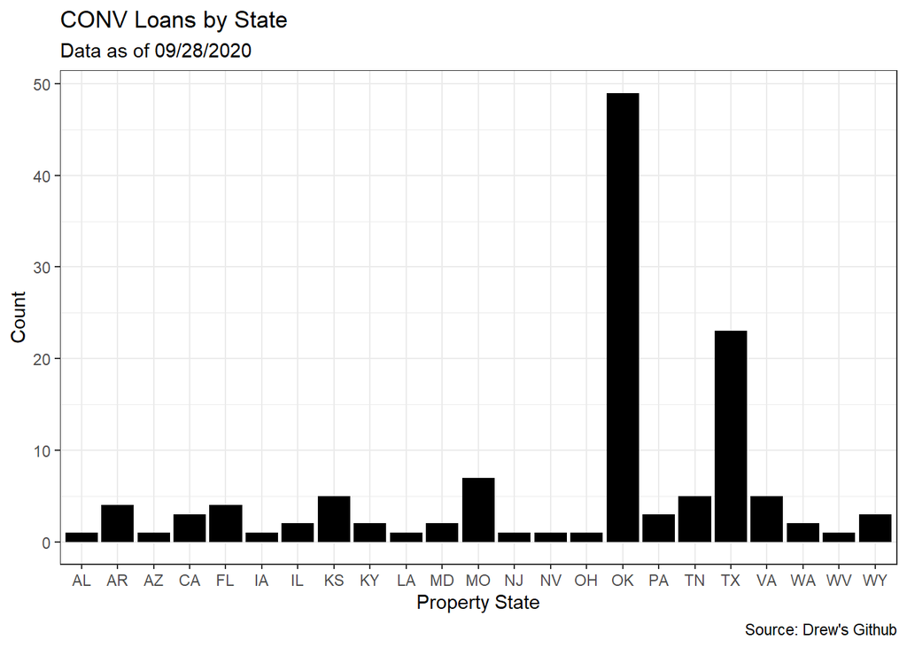

```r
plot_type <- function(type, color){
  df_all %>% filter(TYPE == type) %>%
  ggplot() +
  geom_bar(aes(x = STATE), fill = color)  +
  labs(title = paste0(type,' Loans by State') ,
       subtitle = 'Data as of 09/28/2020',
       y="Count",
       x="Property State",
       caption = 'Source: Drew\'s Github')  +
  theme_bw()
}

# Let's plot them all again now.
plot_type('CONV', 'black')
```

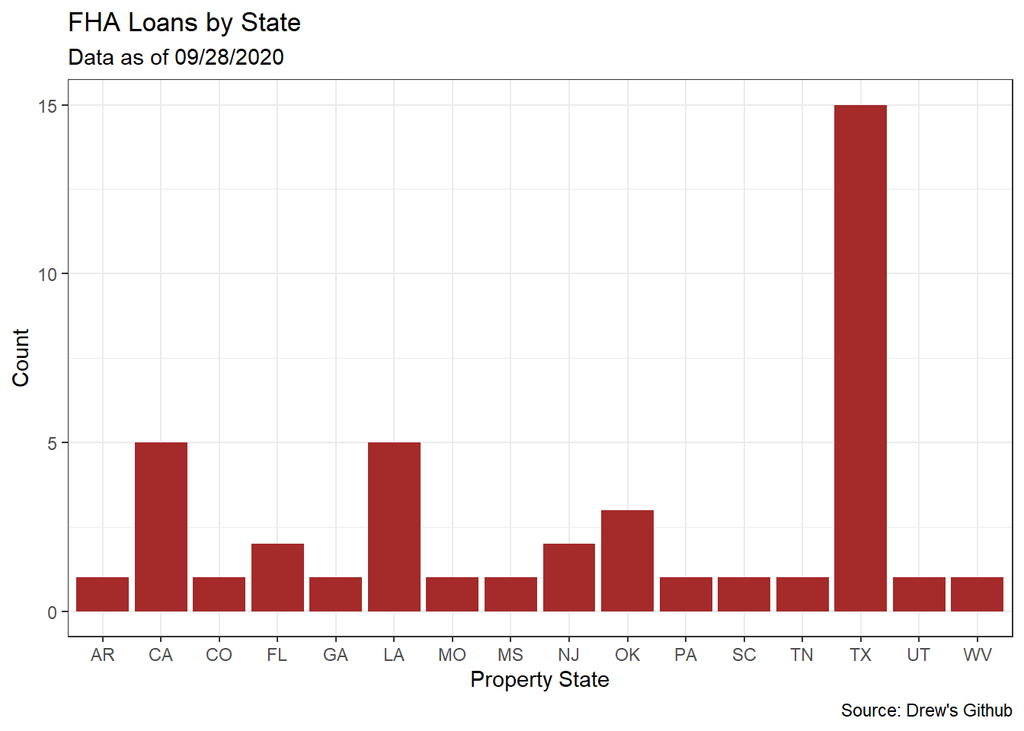

```r
plot_type('FHA', 'brown')
```

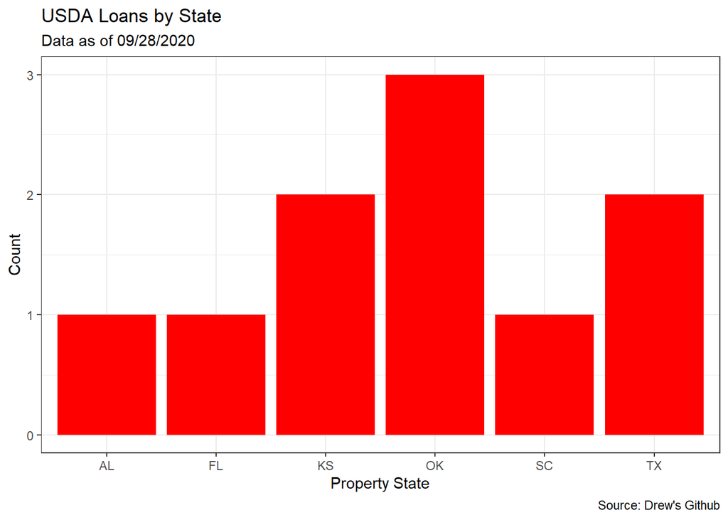

```r
plot_type('USDA', 'red')
```

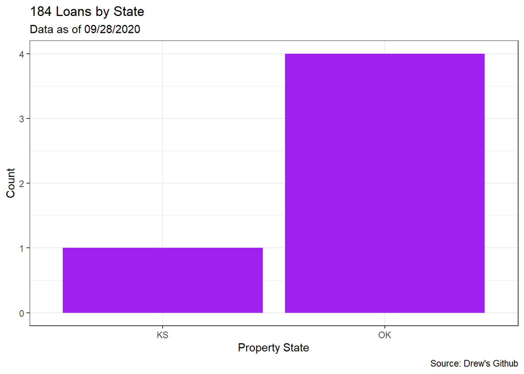

```r
plot_type('184', 'purple')
```

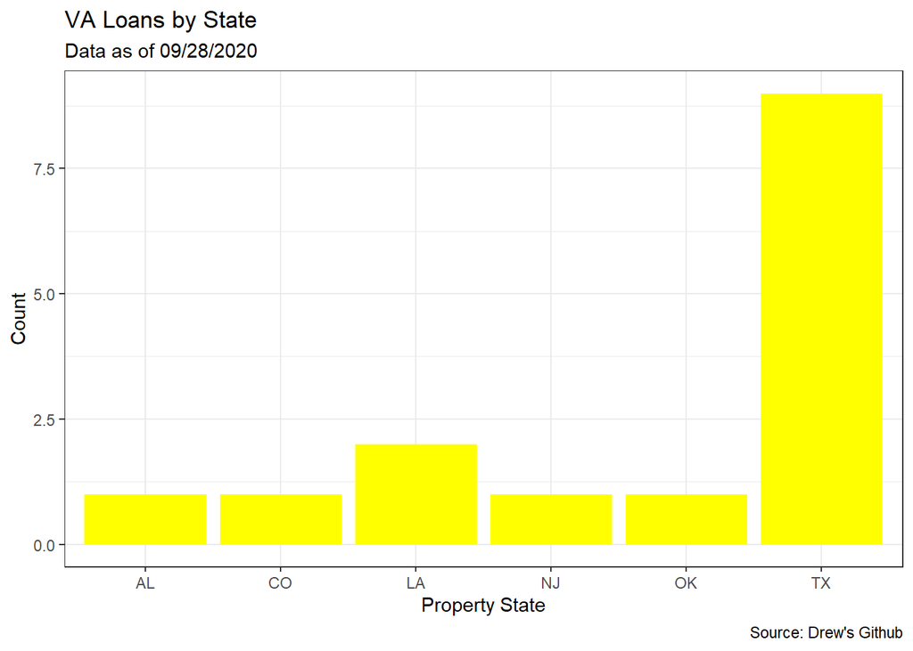

```r
plot_type('VA', 'yellow')
```

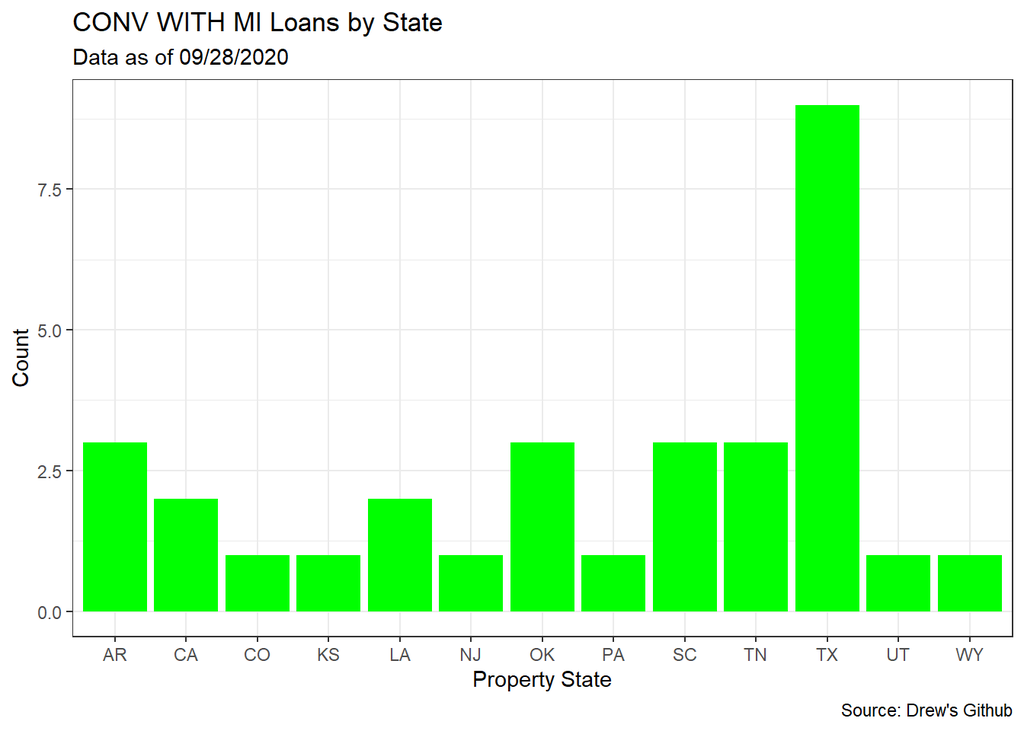

```r
plot_type('CONV WITH MI', 'green')
```

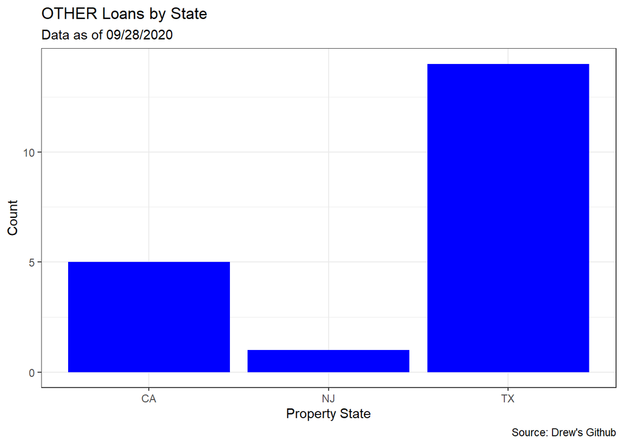

```r
plot_type('OTHER', 'blue')
```

### Functions in Context

There are some instances where creating a function is a waste of time. For instance, if you only have to perform a task once in your script, it could be an unnecessary hassle to build a function above it only to run it once. You should use functions when you are going to have to copy/paste a chunk of code more than a couple of times. Likewise, if the function is performing only one or two lines of code, it could be unnecessary to build it when you could just write the couple of lines where they need to go.

The rest of the week we will spend adding tools to your list to help you code more efficiently. Wednesday is Conditionals 19.4, and Friday is Loops 21.